# R Notebook for Cochrane systematic review on pNAAT for SARS-CoV-2

This is an [R Markdown](http://rmarkdown.rstudio.com) Notebook including code for all analyses within the Cochrane Review on Pooled versus individual nucleic acid amplification testing (pNAAT) for detection of active SARS-CoV-2 infection. It requires the following datasets

- pnaat_desc_study.csv
- pnaat_desc.csv

# 1. Preliminaries

## 1.1 Check working directory

Open the R project associated with this notebook to ensure the working directory is set to ~/Cochrane-DTA-review-pNAAT-for-SARS-CoV-2

## 1.2 Load packages required

This project will initialise *renv* when opened. The R package *renv* creates a record of packages required for the project in a linked private package library. This ensures

- Package installations do not over-write your existing (global) package libraries.
- Package versions are the same as those used within this project.

The following call should install (or copy across from your existing global library) packages that are required for the project

```r
renv::restore()
```

```r
library(gtsummary) # to enable creation of print-ready tables
library(gt) # to enable creation of print-ready tables
library(robvis) # for producing risk of bias summary figures
library(lattice)
library(patchwork) # for composite figures
library(mada) # for forest plots
library(metafor) # for forest plots
library(mgcv) # For exploring non-linear relationships between covariates and outcomes using GAM.
library(lme4) # for generalised linear mixed model (GLMM) regression analysis #
library(effects) # To obtain and plot coefficients and residuals from GLM(M)
library(msm) # enables calculation of DOR confidence intervals by delta-method #
library(ggeffects) # provides easy conversion of coefficients to predicted probabilities
library(partR2) # calculates semi-partial (part) R2 indicating % total variance explained by fixed effects of explanatory varaibles in a glmm.
library(DHARMa) # For residual diagnostics on generalised linear models
library(car) # For identifiying multi-colinearity by variable inflation factors (vif)
library(merTools) # For boostrap confidence intervals around fixed effects etc.
library(sjPlot) # For plotting predicted probabilities and model outputs
library(sjmisc)
library(sjlabelled)
library(lmtest)# allows comparison of nested models
library(meta4diag) # allows for Bayesian GLMM
library(rjags)
library(bamdit) # allows for Bayesian GLMM
library(binom) # allows calculation of exact binomial and Bayesian confidence intervals
library(LearnBayes) # For defining priors
library(ggpubr) # Assistance with graphics
library(GGally)# additional plotting functions
library(ggh4x) # additional plotting functions
library(gridExtra) # Combining plots generated in base R
library(lattice) # For Q-Q plots
library(tidyverse) # to enable 'tidy' collection of packages, including dplyr, ggplot2, purrr, forcats, readr
library(splines)
library(sjstats) # For Spearman's rank with boostrap 95% CI
```

## 1.3 Read in data and label

Read in the csv files “pnaat_desc_study” and “pnaat_desc” and prepare for descriptive statistics and meta-analysis.

### 1.3.1 Load and prepare study level data

```r
meta_study <- read_csv("pnaat_desc_study.csv", col_types =cols(
  wbgroup = col_factor(levels= c("High income","Upper-middle income",
                                 "Lower-middle income","Low income"),
                                              ordered=TRUE),
  country = col_factor(),
  num_cohort = col_factor(),
  num_test = col_factor(),
  pubstat = col_factor(levels= c("Peer-reviewed and published",
                                 "Peer-reviewed pre-print",
                                 "Non-peer reviewed pre-print"),
                                              ordered=TRUE),
  quality = col_factor()))

meta_study <- meta_study %>% mutate (n_test = fct_relevel(
num_test,"1","2","3","5-8"))
meta_study <- meta_study %>% mutate (n_cohort = fct_relevel(
num_cohort, "1","2","3-5"))
```

### 1.3.2 Load and prepare test-evaluation level data

```r
# Load test evaluation level data and define variables
metadata <- read_csv ("pnaat_desc.csv", col_types = cols(
  wbgroup = col_factor(),
  country = col_factor(),
  pubstat = col_factor(levels= c("Peer-reviewed and published",
                                 "Peer-reviewed pre-print",
                                 "Non-peer reviewed pre-print"),
                                              ordered=TRUE),
  pool_size_gp = col_factor(levels=c("2","4 to 7", "8 to 15","16 to 31",
                                     "32+"),ordered=TRUE),
  symptoms = col_factor(levels=c("Asymptomatic","Mixed","Symptomatic")),
  naat = col_factor(levels=c("RT-PCR",
                         "Digital RT-PCR", "TMA", "Cartridge-based RT-PCR")),
  sample_pool = col_factor(),
  sample = col_factor(),
  pool_type = col_factor(),
  quality = col_factor(),
  modified_protocol = col_factor(),
  modint = col_factor(levels=c("lower","standard","higher")),
  pnaat = col_factor(),
  targets_for_pos = col_factor(levels=c("1 of 1", "1 of 2", "1 of 3",
                                        "2 of 2","2 of 3")),
  target = col_factor(levels=c("E","E, N, RdRp","E, Orf1ab","E, RdRp",
                               "N", "N, Orf1ab","N, Orf1ab, S",
                               "N1, N2","N1, N3","Orf1ab")),
  storage = col_factor(),
  ref_std_same_sample = col_logical(),
  refstd_same_assay = col_logical(),
  refstd_same_time = col_logical(),
  refst_same_cutoff = col_logical(),
  regulatory_status = col_factor(),
  index_assay = col_factor(),
  refstd_assay = col_factor()))

# Transform variables for further analysis
metadata <- metadata %>% mutate(log2p = log(pool_size,2))
metadata <- metadata %>% mutate(log2lod = log(lod,2))
metadata <- metadata %>% mutate(tma = if_else(naat=="TMA",1,0))
metadata <- metadata %>% mutate(rtpcr = if_else(naat=="RT-PCR",1,0))
metadata <- metadata %>% mutate(cbpcr = if_else(naat=="Cartridge-based RT-PCR",1,0))
metadata <- metadata %>% mutate(ddpcr = if_else(naat=="Digital RT-PCR",1,0))
metadata <- metadata %>% mutate(multitube = if_else(
                                    sample_pool=="swab multitube",1,0))
metadata <- metadata %>% mutate(swabrna = if_else(
                                    sample_pool =="swab extracted RNA",1,0))
metadata <- metadata %>% mutate(salivadirect = if_else(
  sample_pool=="saliva direct",1,0))
metadata <- metadata %>% mutate(salivarna = if_else(
  sample_pool=="saliva extracted RNA",1,0))
metadata <- metadata %>% mutate(swabmedia = if_else(
  sample_pool=="swab media",1,0))
metadata <- metadata %>% mutate(rna = if_else(
  pool_type=="RNA",1,0))
```

### 1.3.3 Load and prepare cohort level data

```r
# Create cohort level data
meta_cohort <- metadata %>%
  group_by(cohort_id,symptoms,quality) %>%
  summarise(maxparticipant = max(totalsamples),
            maxdisease = max(disease_p),
            maxno_disease=max(disease_n),
            maxweak_pos = max(weak_pos))
meta_cohort <- meta_cohort %>% mutate(positivity = maxdisease/maxparticipant*100)
```

### 1.3.4 Label data

```r
meta_study <- meta_study %>% var_labels (
  study_id = "Number of studies",
  wbgroup = "Country income level classification (World Bank 2020)",
  pubstat = "Publication and peer-review status",
  n_cohort = "Number of cohorts per study",
  n_test = "Number of tests per study")

meta_cohort <- meta_cohort %>% var_labels (
  cohort_id = "Number of cohorts",
  maxparticipant = "Total participants tested (n)",
  maxdisease = "Total participants with disease (positives) (n)",
  maxno_disease = "Total participants without disease (negatives) (n)",
  maxweak_pos = "% Positives with low viral load per cohort",
  positivity = "% Test positivity per cohort",
  symptoms = "Symptom status of cohort")

metadata <- metadata %>% var_labels(
  study_id = "Number of studies",
  wbgroup = "Country income level classification (World Bank 2020)",
  pubstat = "Publication and peer-review status",
  cohort_id = "Cohorts",
  cohort = "Cohorts within study",
  t_p = "True positives",
  f_p = "False positives",
  t_n = "True negatives",
  f_n = "False negatives",
  eval_id = "Number of test evaluations",
  disease_p = "Infected with SARS-CoV-2",
  disease_n = "Not infected with SARS-CoV-2",
  totalsamples = "Total participants",
  pnaat = "pNAAT design",
  pool_size = "Pool size (n)",
  pool_size_gp = "Pool size",
  symptoms = "Symptom status",
  naat = "Test technology",
  sample_pool = "Sample type and pooling method",
  sample = "Sample type",
  pool_type = "Pooling method",
  weak_pos = "% Weak positives (low VL)",
  multipos = "% Pools containing >1 positive sample",
  quality = "Eligibility for meta-analysis",
  positivity_rate = "% Test positivity ",
  lod = "Limit of detection (copies per mL)",
  targets_for_pos = "Number of targets for positive in index pool test",
  target = "Gene targets for index test",
  num_target = "Number of targets assessed",
  modified_protocol = "Modified from IFU or protocol",
  modified_interpret = "Modified interpretation",
  ref_std_same_sample = "Reference standard based on same sample",
  refstd_same_assay = "Reference standard based on same NAAT assay",
  refstd_same_time = "Index test performed at same time as reference standard",
  refst_same_cutoff = "Reference standard uses same Cq cut-off",
  regulatory_status = "Index test regulatory status",
  storage = "Storage before index test",
  disease35_p = "Infected with SARS-CoV-2 by cut-off Cq 35",
  disease35_n = "Not infected with SARS-CoV-2 by cut-off Cq 35",
  t35_p = "True positives for cut-off of Cq 35",
  f35_p = "False positives for cut-off of Cq 35",
  t35_n = "True negatives for cut-off of Cq 35",
  f35_n = "False negatives for cut-off of Cq 35",
  index_assay = "Index test brand",
  refstd_assay = "Reference standard brand")
```

### 1.3.5 Prepare datasets for metaanalysis

Reshape the ‘metadata’ tibble (created above) for bivariate binomial meta-analysis. The new tibble called ‘Y’ incorporates:

- One line each for data needed for sensitivity (diseased and true positives) and specificity (not diseased and true negatives) within each test evaluation,
- Dummy variables indicating rows referring to sensitivity or specificity
- Data for all other variables duplicated for sensitivity and specificity

```r
# convert metadata to dataframe for glmer compatibility
ma2 <- as.data.frame(metadata)

# transform covariates of proportions by folded square root (sQRT(x)-SQRT(1-x))
ma2 <- ma2 %>% mutate(weak_posfold = weak_pos^(1/2)-(1-weak_pos)^(1/2))
ma2 <- ma2 %>% mutate(positivity_ratefold = positivity_rate^(1/2)-(1-positivity_rate)^(1/2))
ma2 <- ma2 %>% mutate(multiposfold = multipos^(1/2)-(1-multipos)^(1/2))


# Create additional variables and reshape for bivariate analysis

ma2$n1 <- ma2$t_p + ma2$f_n # define number with disease
ma2$n0 <- ma2$t_n + ma2$f_p # define number without disease
ma2$true1 <- ma2$t_p # define true positives
ma2$true0 <- ma2$t_n # define true negatives
ma2$testeval <- 1:73 #give unique study id
ma2 <- ma2 %>% slice_head(n=73)

Y1 <- reshape(ma2, direction="long",
               varying=list(c("n1","n0"), c("true1","true0")),
               timevar="sens",times=c(1,0),v.names=c("n","true"))

Y1 <- Y1 %>% var_labels(
  n = "Number by reference standard",
  true = "Number by index test")
Y1 = Y1[order(Y1$study),]
Y1$spec <- 1-Y1$sens
Y1se <- Y1 %>% filter(sens==1)
Y1se$naat <- dplyr::recode(Y1se$naat, "Cartridge-based RT-PCR" = "RT-PCR")
Y1se$naat <- forcats::fct_relevel(Y1se$naat,"RT-PCR")
Y1se$naat = relevel(Y1se$naat, ref="RT-PCR")


# Bivariate model datasets
Y1mp <- Y1 %>% filter(pnaat=="Minipool")  # for minipool (all sizes) #
Y1mp$naat <- dplyr::recode(Y1mp$naat, "Digital RT-PCR" = 2)
Y1mp$naat <- dplyr::recode(Y1mp$naat, "TMA" = 3)
Y1mp <- Y1mp %>% mutate(outcome = true/n)
y1mat <- Y1 %>% filter(pnaat=="Matrix")  # for matrix #
y1com <- Y1 %>% filter(pnaat=="Combinatorial")  # for combinatorial #

# Univariate model datasets
y1semp <- Y1se %>% filter(pnaat=="Minipool")  # for minipool (all sizes) #
y1semat <- Y1se %>% filter(pnaat=="Matrix")  # for matrix #
y1secom <- Y1se %>% filter(pnaat=="Combinatorial")  # for combinatorial

# Further data labeling and transformations
y1semp <- y1semp %>% var_labels(
  naat = "NAAT type",
  reg = "Regulatory approved test",
  weak_posfold = "Positives with low viral load (fsr)",
  multiposfold = "Pools with >1 positive sample (fsr)",
  positivity_ratefold="Test positivity rate (fsr)",
  log2p = "Log 2 pool size",
  log2lod = "Log 2 limit of detection (copies/mL)",
  modified_interpret = "Modified pool test cut-off",
  modified_protocol = "Modified test protocol")
y1semp <- y1semp %>% mutate (modified_protocol=as.factor(modified_protocol))
y1semp<- y1semp %>% mutate(reg = as.factor(reg))
y1semp<- y1semp %>% mutate(sensitivity = t_p/disease_p)

# Grand-mean centre all continuous variables
gmc2 <- function(x) {
    xcenter = mean(x)
    x - xcenter
}

y1semp <- y1semp %>% mutate(across(c(weak_posfold, positivity_ratefold, multiposfold, modified_interpret, log2lod, log2p, pool_size, weak_pos), ~gmc2(.x), "{.col}"))
```

# 2. Descriptive Statistics

## 2.1 Table 1 Description of studies

Generate Table 1.

```r
# Select variables for each sub-table
meta_top <- meta_study %>% dplyr::select(study_id, wbgroup,pubstat,n_cohort, n_test, quality)

meta_mid <- meta_cohort %>% dplyr::select(cohort_id, maxparticipant, maxdisease,
                                   maxno_disease, positivity,
                                   maxweak_pos, symptoms, quality)

meta_low <- metadata %>% dplyr::select(eval_id, pnaat, pool_size_gp,
                                       multipos, naat,
                                sample, pool_type, index_assay,
                                regulatory_status, lod, targets_for_pos,
                                target, refstd_same_time, storage,
                                ref_std_same_sample, refstd_same_assay,
                                refst_same_cutoff, quality)

# Create sub-tables
t1<- tbl_summary(meta_top, by=quality, statistic = list(
  all_continuous() ~ "{median} ({p25} to {p75})",
  study_id ~"{n_distinct}"))  %>% add_overall() %>%
  modify_header(update = list(stat_0 ~ "**All**" ,
                              stat_1 ~ "**Single-gate**",
                              stat_2 ~ "**Two-gate**"))
t2<- tbl_summary(meta_mid, by=quality, statistic = list(
  all_continuous() ~ "{median} ({p25} to {p75})",
  cohort_id ~"{n_distinct}",
  maxparticipant ~"{sum}",
  maxdisease ~"{sum}",
  maxno_disease ~"{sum}")) %>%  add_overall()

t3 <- tbl_summary(meta_low, by=quality, statistic = list(
  all_continuous() ~ "{median} ({p25} to {p75})",
  eval_id ~"{n_distinct}"))  %>% add_overall()

# Stack the sub-tables into combined final table
stacked <- tbl_stack(list(t1,t2,t3)) %>% modify_spanning_header(
  c("stat_1", "stat_2") ~ "**Eligible for primary meta-analysis**") %>%
  modify_footnote(update = all_stat_cols() ~ "median (IQR) or n (%)")

stacked <- stacked %>% as_gt() %>% fmt_markdown(columns = TRUE) %>%
  gt::tab_source_note(gt::md("**LDT:** laboratory developed test; **pNAAT:** pooled nucleic acid amplification test; **RT-PCR:** reverse-transcription polymerase chain reaction; **TMA:** transcription mediated amplification;"))%>%
  tab_row_group(
    "Test evaluations", rows=30:114)  %>% tab_row_group(
    "Cohorts", rows=20:29)  %>% tab_row_group(
    "Studies", rows=1:19) %>% opt_table_font(
      font= google_font("Source Sans Pro")) %>% tab_options(
      row_group.background.color = "#CFD7E4", row_group.font.weight = "bold",
      table_body.hlines.color ="black",
      row_group.border.bottom.color = "black",
       row_group.border.bottom.width = px(1),
       row_group.border.top.width = px(1),
        heading.border.bottom.width = px(1),
        heading.border.bottom.color = "black",
        row_group.border.top.color = "black",
       footnotes.border.bottom.color = "black",
       footnotes.border.bottom.width = px(1),
       column_labels.border.top.color = "black",
       column_labels.border.top.width = px(1),
       table_body.border.top.color="black",
       table_body.border.bottom.color="black",
       table_body.border.top.width =px(1),
       table_body.border.bottom.width=px(1),
      source_notes.border.bottom.width = px(1),
      source_notes.border.bottom.color ="black",
       table.font.size = px(12))
stacked
```

| **Characteristic** | **All**<sup>1</sup> | **Eligible for primary meta-analysis** **Single-gate**<sup>1</sup> | **Eligible for primary meta-analysis** **Two-gate**<sup>1</sup> |
| --- | --- | --- | --- |
| Studies |  |  |  |
| Number of studies | 27 | 15 | 12 |
| Country income level classification (World Bank 2020) |  |  |  |
| High income | 17 (63%) | 8 (53%) | 9 (75%) |
| Upper-middle income | 4 (15%) | 3 (20%) | 1 (8.3%) |
| Lower-middle income | 6 (22%) | 4 (27%) | 2 (17%) |
| Low income | 0 (0%) | 0 (0%) | 0 (0%) |
| Publication and peer-review status |  |  |  |
| Peer-reviewed and published | 18 (67%) | 10 (67%) | 8 (67%) |
| Peer-reviewed pre-print | 2 (7.4%) | 2 (13%) | 0 (0%) |
| Non-peer reviewed pre-print | 7 (26%) | 3 (20%) | 4 (33%) |
| Number of cohorts per study |  |  |  |
| 1 | 19 (70%) | 10 (67%) | 9 (75%) |
| 2 | 5 (19%) | 4 (27%) | 1 (8.3%) |
| 3-5 | 3 (11%) | 1 (6.7%) | 2 (17%) |
| Number of tests per study |  |  |  |
| 1 | 11 (41%) | 6 (40%) | 5 (42%) |
| 2 | 7 (26%) | 6 (40%) | 1 (8.3%) |
| 3 | 3 (11%) | 1 (6.7%) | 2 (17%) |
| 5-8 | 6 (22%) | 2 (13%) | 4 (33%) |
| Cohorts |  |  |  |
| Number of cohorts | 41 | 23 | 18 |
| Total participants tested (n) | 23,789 | 12,592 | 11,197 |
| Total participants with disease (positives) (n) | 1,639 | 757 | 882 |
| Total participants without disease (negatives) (n) | 22,153 | 11,836 | 10,317 |
| % Test positivity per cohort | 8.0 (4.8 to 10.7) | 6.2 (4.7 to 8.7) | 10.0 (5.5 to 12.5) |
| % Positives with low viral load per cohort | 0.14 (0.04 to 0.35) | 0.10 (0.02 to 0.23) | 0.35 (0.04 to 0.51) |
| Symptom status of cohort |  |  |  |
| Asymptomatic | 4 (9.8%) | 3 (13%) | 1 (5.6%) |
| Mixed | 25 (61%) | 10 (43%) | 15 (83%) |

[output cut: 87 more lines]

**LDT:** laboratory developed test; **pNAAT:** pooled nucleic acid amplification test; **RT-PCR:** reverse-transcription polymerase chain reaction; **TMA:** transcription mediated amplification;  
<sup>*1*</sup> median (IQR) or n (%)

# 3. Review of data

## 3.1 Asssessment of heterogeneity

### 3.1.1 Visual inspection of paired forest plots

Visual inspection of paired forest plots for all evaluations suggests:

- No heterogeneity in results for *combinatorial* or *matrix* pNAAT designs as very small number of eligible studies. Sensitivity and specificity likely to be best summarised by binomial exact estimates and confidence intervals.
- Substantial heterogeneity in sensitivity seen in *minipool* designs but specificity approaching 100% across all evaluations.

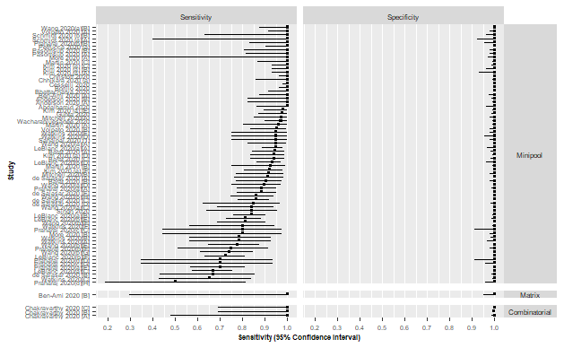

```r
# Derive exact binomial confidence intervals for all studies
uni <- binom.confint(Y1$true, Y1$n, conf.level = 0.95, methods = "exact")
uni <- uni %>% dplyr::select(mean,lower,upper)
uniex <- uni %>% dplyr::rename(c(est=mean, lci =lower, uci =upper))
Y1plus <- cbind(Y1,uniex)
Y1plus <- Y1plus  %>% dplyr::rename (Study=test_eval_id )
Y1plus <- Y1plus %>% dplyr::mutate (estse = sens*est)
Y1plus <- Y1plus %>% mutate(Study= fct_reorder(Study, estse))
Y1plus$sens <- recode_factor(Y1plus$sens, '1' = "Sensitivity", '0' = "Specificity")

set_theme(theme_classic2)
fp = ggplot(Y1plus, aes(x = Study,y = est, ymin = lci, ymax = uci))+
    geom_pointrange(aes(ymin= lci, ymax= uci), shape = 15, size = 0.1,
                    color = "black", fill="white", width=0.1,cex=1, )+
    coord_flip()+
    xlab('Study')+
    scale_y_continuous("Sensitivity (95% Confidence Interval)",
                       breaks=seq(0,1,0.1))+
    facet_grid (pnaat~sens, drop=TRUE, scales="free_y")+
    force_panelsizes(rows = c(10,0.3,0.5), cols=c(3,3)) +
    theme(axis.text=element_text(size=5),
        axis.title=element_text(size=6, face="bold"),
        strip.text.x = element_text(angle=0, size = 6),
         panel.grid.major.y = element_blank())+
  theme(strip.text.y = element_text(angle=0, size = 6))
fp
```

### 3.1.2 Formally test heterogeneity

We used the *madad* function of the *mada* package to test for heterogeneity in sensitivity and specificity (Ho: no heterogeneity, H1: heterogeneity)

```r
# Use 'madad' function
confmatrix <- metadata %>% dplyr::select(test_eval_id,t_p,f_n,f_p,t_n, pool_size_gp, disease_p, disease_n, pool_size, pnaat, naat, sample, pool_type)
confmatrix <- confmatrix %>% rename(c(Study = test_eval_id, TP=t_p, FN=f_n, FP=f_p, TN=t_n))
confmatrix <- confmatrix %>% mutate (fpr = FP/disease_n)
confmatrix <- confmatrix %>% mutate (point = TP/disease_p)
confmatrix <- confmatrix %>% mutate (n=TP+FP+TN+FN)
hg <- madad(confmatrix)
heterogeneity_test_sensitivity <- c(hg[[c(4,1)]],hg[[c(4,2)]],hg[[c(4,3)]])
heterogeneity_test_specificity <- c(hg[[c(5,1)]],hg[[c(5,2)]],hg[[c(5,3)]])
hgall <- rbind(heterogeneity_test_sensitivity,heterogeneity_test_specificity)
Outcome <- c("Sensitivity","Specificity")
hgall2 <-cbind(Outcome,hgall)
hgall2 <- as_tibble(hgall2)
hgall2 <- hgall2 %>% rename (p = V4)
hgall2 <- hgall2 %>% rename (chi2 = "X-squared")
hgall2$p <- as.numeric (hgall2$p)
hgall2$chi2 <- as.numeric (hgall2$chi2)
hgall2 <- hgall2 %>% mutate_if(is.numeric, round, 4)
gt_hgall <- gt(data = hgall2)
gt_hgall %>% tab_header(title = "Test for equality of sensitivities and specificities")
```

Test for equality of sensitivities and specificities

| Outcome | chi2 | df | p |
| --- | --- | --- | --- |
| Sensitivity | 329.8708 | 72 | 0.0000 |
| Specificity | 45.2994 | 72 | 0.9942 |

## 3.2 Check for threshold effects

We investigated a threshold effect: i.e, a trade-off of sensitivity and specificity as positivity threshold is varied.

### 3.2.1 Descriptive plots

Descriptive plots of observed and estimated sensitivity and 1-specificity (FPR) in ROC space show an apparent lack of association, given specificity is ~100% in all studies. While the pool-test stage of a pooling method can result in ‘FP’ pools, subsequent re-testing of samples within these pools, or analoguous algorithmic deconvoluting, largely excludes FP individual sample results.

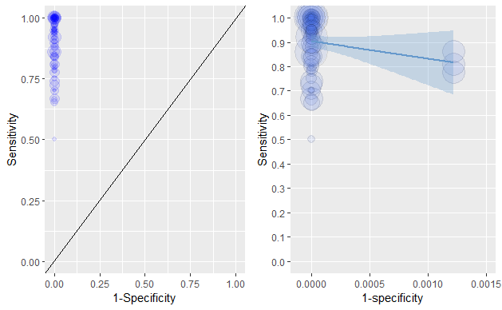

```r
# Descriptive plots
p1cor <- ggplot (confmatrix, aes(x= fpr, y=point, size=n))+
  geom_point(alpha=0.1, colour ="blue")+
  ylim(0,1)+
  xlim(0,1)+
  geom_abline(intercept = 0, slope = 1)+
  labs(y= "Sensitivity", x = "1-Specificity")+
  theme(legend.position = "none")

p2cor <- plotdata(confmatrix2, two.by.two=TRUE, alpha.p=0.1, max.size=15)+
  geom_smooth(method=lm , alpha = 0.3, color="#6699cc", fill="#6699cc", se=TRUE)+
   theme (panel.grid.minor=element_blank())+
   theme (legend.position = "none")+
  scale_x_continuous("1-specificity", limits = c(-0.0001, 0.0015))+
  scale_y_continuous ("Sensitivity", breaks=seq(0,1,0.1), limits = c(0,1))

ggarrange(p1cor, p2cor)
```

### 3.2.2 Correlation of Sensitivity and FPR

We used the *crosstable_statistics* function of the *sjtools* package to derive a Spearman’s rank correlation of sensitivity and FPR, weighted by overall number tested (n).

```r
cts<- crosstable_statistics(data=confmatrix, x1=fpr, x2=point, statistics="spearman", weights= corrfprse$totalsamples)
cts2 <- c(cts$estimate, cts$p.value)
z = -0.862 + sqrt (0.743-(2.404*log(cts$p.value)))
int = 1.96*(cts$estimate/z)
lci = cts$estimate + int
uci = cts$estimate - int
cts2 <- c(cts$estimate, lci ,uci, cts$p.value)
param <- c("rho","lci","uci","p" )
cts3 <- cbind(param,cts2)
as.tibble(cts3)
```

| param | cts2 |
| --- | --- |
| rho | -0.0985754103913191 |
| lci | -0.327861380423816 |
| uci | 0.130710559641178 |
| p | 0.406699676154627 |

### 3.2.3 Reitsma approach for summary point in ROC space

We used the *reitsma* function from the *mada* package to attempt to fit a summary point and predictive interval in ROC space for minipool pNAAT design only.

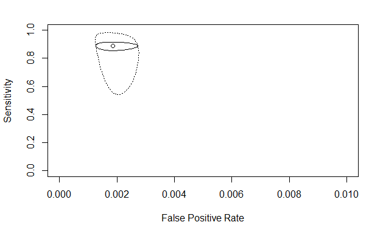

```r
confmatrix2 <- confmatrix %>% mutate(n1 = TP+FN)
confmatrix2 <- confmatrix2 %>% mutate(n2 = FP+TN)
confmatrix2 <- confmatrix2 %>% mutate(Study =as.character(Study))

reit<- reitsma(confmatrix2,TP="TP", FN="FN", FP="FP", TN="TN",alphasens = 1, alphafpr = 1,correction = 0.5, correction.control = "all",method = "reml")
plot(reit, extrapolate = FALSE, plotsumm = TRUE, level = 0.95,
     ylim = c(0,1), xlim = c(0,0.01), pch = 1, sroclty = 1, sroclwd = 1,
     predict = TRUE, predlty = 3, predlwd = 1)
```

```r
summary(reit)
```

```
Call:  reitsma.default(data = confmatrix2, TP = "TP", FN = "FN", FP = "FP",
    TN = "TN", alphasens = 1, alphafpr = 1, correction = 0.5,
    correction.control = "all", method = "reml")

Bivariate diagnostic random-effects meta-analysis
Estimation method: REML

Fixed-effects coefficients
                  Estimate Std. Error       z Pr(>|z|) 95%ci.lb 95%ci.ub
tsens.(Intercept)    2.076      0.125  16.642    0.000    1.832    2.321
tfpr.(Intercept)    -6.287      0.157 -39.937    0.000   -6.596   -5.978
sensitivity          0.889          -       -        -    0.862    0.911
false pos. rate      0.002          -       -        -    0.001    0.003

tsens.(Intercept) ***
tfpr.(Intercept)  ***
sensitivity
false pos. rate
---
Signif. codes:  0 ‘***’ 0.001 ‘**’ 0.01 ‘*’ 0.05 ‘.’ 0.1 ‘ ’ 1

Variance components: between-studies Std. Dev and correlation matrix
      Std. Dev  tsens  tfpr
tsens    0.768  1.000     .
tfpr     0.041 -1.000 1.000

  logLik      AIC      BIC
 441.081 -872.162 -857.244

AUC:  0.99
Partial AUC (restricted to observed FPRs and normalized):  0.99

HSROC parameters
      Theta      Lambda        beta sigma2theta sigma2alpha
    -13.397      27.752      -2.935       0.000       0.125
```

### 3.2.4 Bayesian approach for summary point in ROC space

We used the *metadiag* function from the *bamdit* package to take a Bayesian approach to fitting a summary point and posterior predictive intervals in ROC space for minipool pNAAT design only.

```r
# Filter to obtain only minipool studies


result <- metadiag(confmatrix2, two.by.two=TRUE, re = "normal", re.model = "DS", link = "logit", sd.Fisher.rho = 1.7, nr.burnin = 1000, nr.iterations = 5000, nr.chains = 4, r2jags = TRUE)
```

[output not shown]

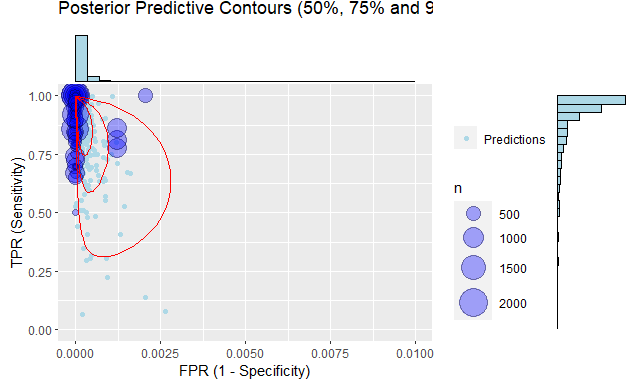

```r
plot(result, level = c(0.5,0.75, 0.95), parametric.smooth = TRUE, limits.x = c(0,0.01))
```

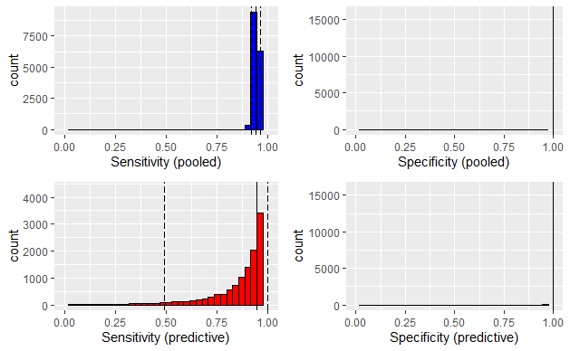

```r
plotsesp(result)
```

## 3.3 Data structure for random effects

We sought to resolve two issues before proceeding to summary effects:

To explore these options we used the glmer function in “lme4” to fit integer only models to the largest planned synthesis (all minipools combined, n = 69 test evaluations, n =37 cohorts)

### 3.3.1 model 1 bivariate binomial random-effects with unstructured covariance matrix

Use glmer to fit an integer only bivariate binomial mixed (random-effects) meta-analysis with an unstructured covariance matrix. We observe * Confirms substantial between-studies variance among mini-pool designs * Correlation of fixed effects is confirmed to be low (~0.15). * Covariance in random effects = 1 suggesting over-fitting and need to reduce model complexity * Overall suggests a similar model with either a zero correlation covariance matrix (model 2 below) or considering no random-effects in specificity (model 3 below) more appropriate.

```r
ymp_mod1 <- glmer (formula= cbind(true,n-true)~0+sens+spec+(0+sens+spec|testeval),
                    data = Y1mp,family=binomial,nAGQ=1,verbose=0)
ymp_mod1_sum <- summary(ymp_mod1)
ymp_mod1_sum
```

```
Generalized linear mixed model fit by maximum likelihood (Laplace
  Approximation) [glmerMod]
 Family: binomial  ( logit )
Formula: cbind(true, n - true) ~ 0 + sens + spec + (0 + sens + spec |
    testeval)
   Data: Y1mp

     AIC      BIC   logLik deviance df.resid
   365.1    379.7   -177.5    355.1      133

Scaled residuals:
     Min       1Q   Median       3Q      Max
-2.71473 -0.01085  0.09386  0.24729  1.09191

Random effects:
 Groups   Name Variance Std.Dev. Corr
 testeval sens 1.835    1.355
          spec 1.741    1.319    1.00
Number of obs: 138, groups:  testeval, 69

Fixed effects:
     Estimate Std. Error z value Pr(>|z|)
sens   2.7704     0.2085  13.288   <2e-16 ***
spec   9.8969     1.0878   9.098   <2e-16 ***
---
Signif. codes:  0 ‘***’ 0.001 ‘**’ 0.01 ‘*’ 0.05 ‘.’ 0.1 ‘ ’ 1

Correlation of Fixed Effects:
     sens
spec 0.149
```

```r
co1 <- ymp_mod1_sum$coeff[1,1]
ci1 <- confint(ymp_mod1, level = 0.95,method = "boot",boot.type = "perc", nsim=200)
plogis(co1)
```

```
[1] 0.9410544
```

```r
plogis(ci1)
```

```
           2.5 %    97.5 %
.sig01 0.7141318 0.8417112
.sig02 0.2703962 0.7310586
.sig03 0.5733875 0.9995273
sens   0.9132433 0.9606731
spec   0.9998583 1.0000000
```

### 3.3.2 model 2 bivariate binomial random-effects with zero covariance matrix

Use glmer to fit an integer only bivariate binomial multi-level (random-effects) meta-analysis with a zero covariance matrix. We observe:

- The estimates for sensitivity (0.941) and specificity (~1.00) are similar to model 1.
- However, the between-studies variance is limited to sensitivity, with between-studies variance in specificity ~0 which is more consistent with observations.
- A model considering no random-effects in specificity (model 3 below) or a univariate model focused on sensitivity (model 4 below) may be more appropriate.

```r
ymp_mod2 <- glmer (formula= cbind(true,n-true)~0+sens+spec+(0+sens|testeval), Y1mp, family=binomial,nAGQ=1,verbose=0)
ymp_mod2_sum <- summary(ymp_mod2)
ymp_mod2_sum
```

```
Generalized linear mixed model fit by maximum likelihood (Laplace
  Approximation) [glmerMod]
 Family: binomial  ( logit )
Formula: cbind(true, n - true) ~ 0 + sens + spec + (0 + sens | testeval)
   Data: Y1mp

     AIC      BIC   logLik deviance df.resid
   364.0    372.8   -179.0    358.0      135

Scaled residuals:
    Min      1Q  Median      3Q     Max
-3.2142 -0.0687  0.1346  0.2685  1.0988

Random effects:
 Groups   Name Variance Std.Dev.
 testeval sens 1.822    1.35
Number of obs: 138, groups:  testeval, 69

Fixed effects:
     Estimate Std. Error z value Pr(>|z|)
sens   2.7635     0.2078   13.30   <2e-16 ***
spec   9.2170     0.5774   15.96   <2e-16 ***
---
Signif. codes:  0 ‘***’ 0.001 ‘**’ 0.01 ‘*’ 0.05 ‘.’ 0.1 ‘ ’ 1

Correlation of Fixed Effects:
     sens
spec 0.000
```

```r
co2 <- ymp_mod2_sum$coeff[1,1]
ci2 <- confint(ymp_mod2, level = 0.95,method = "boot",boot.type = "perc", nsim=200)
plogis(co2)
```

```
[1] 0.940674
```

```r
plogis(ci2)
```

```
           2.5 %    97.5 %
.sig01 0.7304696 0.8399033
sens   0.9155711 0.9603632
spec   0.9997361 1.0000000
```

### 3.3.3 Model 3: Bivariate binomial partial random effects model

Observations:

```r
ymp_mod3 <- glmer (formula= cbind(true,n-true)~0+sens+spec+(0+sens|testeval),
                    data = Y1mp,family=binomial,nAGQ=1,verbose=0)
ymp_mod3_sum <- summary(ymp_mod3)
ymp_mod3_sum
```

```
Generalized linear mixed model fit by maximum likelihood (Laplace
  Approximation) [glmerMod]
 Family: binomial  ( logit )
Formula: cbind(true, n - true) ~ 0 + sens + spec + (0 + sens | testeval)
   Data: Y1mp

     AIC      BIC   logLik deviance df.resid
   364.0    372.8   -179.0    358.0      135

Scaled residuals:
    Min      1Q  Median      3Q     Max
-3.2142 -0.0687  0.1346  0.2685  1.0988

Random effects:
 Groups   Name Variance Std.Dev.
 testeval sens 1.822    1.35
Number of obs: 138, groups:  testeval, 69

Fixed effects:
     Estimate Std. Error z value Pr(>|z|)
sens   2.7635     0.2078   13.30   <2e-16 ***
spec   9.2170     0.5774   15.96   <2e-16 ***
---
Signif. codes:  0 ‘***’ 0.001 ‘**’ 0.01 ‘*’ 0.05 ‘.’ 0.1 ‘ ’ 1

Correlation of Fixed Effects:
     sens
spec 0.000
```

```r
co3 <- ymp_mod3_sum$coeff[1,1]
ci3 <- confint(ymp_mod3, level = 0.95,method = "boot",boot.type = "perc", nsim=200)
plogis(co3)
```

```
[1] 0.940674
```

```r
plogis(ci3)
```

```
           2.5 %    97.5 %
.sig01 0.7278152 0.8442268
sens   0.9167420 0.9604293
spec   0.9998014 1.0000000
```

### 3.3.4 model 4 Sensitivity only model

Use glmer to fit an integer only univariate (outcome is sensitivity only) binomial multi-level (random-effects) meta-analysis Observations

- Depending on method used for ICC calculation, around 35-55% of total variation in sensitivity occurs between test-evaluations.
- A univariate random-effects (glmm) model with test-evaluation at level 2 captures between-study variation efficiently.
- A univariate random-effects (glmm) model with test-evaluation (level 2) nested within study cohorts (level 3) is also suitable but is likely to result in over-fitting.

#### model 4a study as level 2

```r
set.seed(99)
ysemp2 <- glmer (formula= cbind(true,n-true)~ 1+(1|testeval),
                    data = y1semp,family=binomial, nAGQ=1,verbose=0)
ysemp2_sum <- summary(ysemp2)
ysemp2_sum
```

```
Generalized linear mixed model fit by maximum likelihood (Laplace
  Approximation) [glmerMod]
 Family: binomial  ( logit )
Formula: cbind(true, n - true) ~ 1 + (1 | testeval)
   Data: y1semp

     AIC      BIC   logLik deviance df.resid
   341.0    345.4   -168.5    337.0       67

Scaled residuals:
     Min       1Q   Median       3Q      Max
-0.80898 -0.23245 -0.00329  0.69455  1.09880

Random effects:
 Groups   Name        Variance Std.Dev.
 testeval (Intercept) 1.822    1.35
Number of obs: 69, groups:  testeval, 69

Fixed effects:
            Estimate Std. Error z value Pr(>|z|)
(Intercept)   2.7636     0.2078    13.3   <2e-16 ***
---
Signif. codes:  0 ‘***’ 0.001 ‘**’ 0.01 ‘*’ 0.05 ‘.’ 0.1 ‘ ’ 1
```

```r
co4a <- ysemp2_sum$coeff[1,1]
ci4a <- confint(ysemp2, level = 0.95,method = "boot",boot.type = "perc", nsim=200)
plogis(co4a)
```

```
[1] 0.9406742
```

```r
plogis(ci4a)
```

```
                2.5 %    97.5 %
.sig01      0.7283178 0.8505969
(Intercept) 0.9165109 0.9606870
```

#### Model 4b Nested (studies nested within cohorts)

```r
ysemp3 <- glmer (formula= cbind(true,n-true)~ 1+(1|testeval/cohort_id),
                    data = y1semp,family=binomial, nAGQ=1,verbose=0)
ysemp3_sum <- summary(ysemp3)
ysemp3_sum
```

```
Generalized linear mixed model fit by maximum likelihood (Laplace
  Approximation) [glmerMod]
 Family: binomial  ( logit )
Formula: cbind(true, n - true) ~ 1 + (1 | testeval/cohort_id)
   Data: y1semp

     AIC      BIC   logLik deviance df.resid
   343.0    349.7   -168.5    337.0       66

Scaled residuals:
     Min       1Q   Median       3Q      Max
-0.80898 -0.23245 -0.00329  0.69455  1.09880

Random effects:
 Groups             Name        Variance Std.Dev.
 cohort_id:testeval (Intercept) 0.8778   0.9369
 testeval           (Intercept) 0.9438   0.9715
Number of obs: 69, groups:  cohort_id:testeval, 69; testeval, 69

Fixed effects:
            Estimate Std. Error z value Pr(>|z|)
(Intercept)   2.7636     0.2078    13.3   <2e-16 ***
---
Signif. codes:  0 ‘***’ 0.001 ‘**’ 0.01 ‘*’ 0.05 ‘.’ 0.1 ‘ ’ 1
optimizer (Nelder_Mead) convergence code: 0 (OK)
Model is nearly unidentifiable: large eigenvalue ratio
 - Rescale variables?
```

```r
co3c <- ysemp3_sum$coeff[1,1]
ci3c <- confint(ysemp3, level = 0.95,method = "boot",boot.type = "perc", nsim=200)
plogis(co3c)
```

```
[1] 0.9406741
```

```r
plogis(ci3c)
```

```
                2.5 %    97.5 %
.sig01      0.6439537 0.7700642
.sig02      0.6183238 0.7794096
(Intercept) 0.9170958 0.9594724
```

### 3.3.5 Summarising results for minipool

Overall we suggest the following pre-planned schedule for model fits starting at stage 1 and progressing (stage 1 to 4 in order) if overfitting, non-convergence or other model-fit issues 1st stage: Bivariate binomial partial random-effects model 2nd stage: Univariate binomial random-effects model (glmm in lme4) 3rd stage: Univariate binomial fixed-effects model (glm in lme4) 4th stage: Collate confusion matrix numbers and perform binomial.test with binomial exact and/or Bayesian confidence intervals.

```r
#### Summarising results
mptable <- tab_model (ymp_mod2, ymp_mod3, ysemp2, ysemp3, transform=NULL,
                           show.p=FALSE, collapse.ci = TRUE,  show.reflvl = TRUE, show.icc = FALSE, show.obs = FALSE, show.r2 = FALSE, show.loglik = TRUE, show.aic = TRUE, pred.labels=c("Intercept","Weak positives (fsqroot)", "NAAT: digital PCR","NAAT: TMA", "log 2 of pool size","Sample type: saliva","Modified test protocol", "Modified pool test cut-off", "Regulatory approval: yes"),
  dv.labels=c("Bivariate, zero covariance","Bivariate, partial random RE" ,"Univariate 2-level", "Univariate 3-level"))

mptable
```

# 4. Summary estimates of test accuracy

## 4.1 Summary by pNAAT design

### 4.1.1 Combinatorial

Only a single study was identified (Chakraborty 2020 [A-C]) which employed a combinatorial pooled test approach to a representative set of specimens. Three slight variants of the approach were assessed on three cohorts. Since there were 0 FNs and only 1 FP across the three cohorts we decided to sum TP,FP,TN, and FN across the cohorts and to estimate sensitivity and specificity using binomial exact method (and later Bayesian inference - see section 8).

#### Estimate sens and spec (and 95% CIs) using the binomial exact method

```r
ycomsens <-c(binom.test(25,25)$estimate, binom.test(25,25)$conf.int)
ycomspec <-c(binom.test(1765,1766)$estimate, binom.test(1765,1766)$conf.int)
cosum <- rbind(ycomsens,ycomspec)
rowlab <- c("Sensitivity","specificity")
comb_summary <-cbind(rowlab,cosum)
comb<- as.tibble(comb_summary)
comb<- comb %>% rename(Parameter = rowlab, estimate ="probability of success", "lower 95% CI"=V3, "upper 95% CI"=V4)
comb$estimate = as.numeric (comb$estimate)
comb$`lower 95% CI` = as.numeric (comb$`lower 95% CI`)
comb$`upper 95% CI` = as.numeric (comb$`upper 95% CI`)
combgt <- gt(comb)
combgt2 <- combgt %>% fmt_number(columns = c(estimate, "lower 95% CI", "upper 95% CI"),decimals = 3)
combgt2
```

### 4.1.2 Matrix

Only a single study was identified (Ben-Ami 2020 [B]) which employed a matrix pooled test approach to a representative set of specimens.

#### Estimate sens and spec (and 95% CIs) using the binomial exact method

```r
ymatsens <-c(binom.test(3,3)$estimate, binom.test(3,3)$conf.int)
ymatspec <-c(binom.test(72,72)$estimate, binom.test(72,72)$conf.int)
matsum <- rbind(ymatsens,ymatspec)
matsummary <-cbind(rowlab,matsum)
mat<- as.tibble(matsummary)
mat<- mat %>% rename(Parameter = rowlab, estimate ="probability of success", "lower 95% CI"=V3, "upper 95% CI"=V4)
mat$estimate = as.numeric (mat$estimate)
mat$`lower 95% CI` = as.numeric (mat$`lower 95% CI`)
mat$`upper 95% CI` = as.numeric (mat$`upper 95% CI`)
matgt <- gt(mat)
matgt2 <- matgt %>% fmt_number(columns = c(estimate, "lower 95% CI", "upper 95% CI"),decimals = 3)
matgt2
```

### 4.1.3 Minipool

The review identified 69 evaluations of minipool tests across 37 cohorts. A bivariate binomial partial random-effects model (converged considering only random-effects in sensitivity)

```r
set.seed(111)
ymp_modfinal <- glmer (formula= cbind(true,n-true)~0+sens+spec+(0+sens|testeval),
                    data = Y1mp,family=binomial,nAGQ=1,verbose=0)
ymp_modfinal_sum <- summary(ymp_modfinal)
ymp_modfinal_sum
co3 <- ymp_modfinal_sum$coeff[1,1]
ci3 <- confint(ymp_modfinal, level = 0.95,method = "boot",boot.type = "perc", nsim=200)
plogis(co3)
plogis(ci3)
```

# 5 Sub-group analyses

We summarise test accuracy for the following sub-groups of minipool pNAAT:

- 5.1 Pool size groups (only)
- 5.2 NAAT type and Pool size groups
- 5.3 Symptom status and Pool size groups
- 5.4 Sample type and Pool size groups
- 5.5 Pooling method and Pool size groups

## 5.1 Pool size groups

### 5.1.1 Minipool of size 2

Only 3 test-evaluations (from 2 studies) looked at minipool sizes of 2. stage 1: A partial random effects model (mp2a) was singular. stage 2: Univariate random effects model (mp2b) was singular stage 3: Univariate fixed effects model (mp2c) for sensitivity Stage 4: Binomial test with binomial exact 95% CI fit for specificity

```r
#### Stage 1 model
ymp2 <- Y1mp %>% filter(pool_size_gp=="2")
ymp2se <- y1semp %>% filter(pool_size_gp=="2")
mp2a <- glmer (formula= cbind(true,n-true)~0+sens+spec+
(0+sens|testeval), data = ymp2,
family=binomial, nAGQ=1,verbose=0) # fixed + random model
mp2a_sum <- summary(mp2a)

#### Stage 2 model (sensitivity only)
mp2b <- glmer (formula= cbind(true,n-true)~ 1+(1|testeval), data = ymp2se, family=binomial,nAGQ=1,verbose=0) # fixed + random model
mp2b_sum <- summary(mp2b)

#### Stage 3 model (sensitivity only, fixed)
mp2c <- glm (formula= cbind(true,n-true)~ 1, data = ymp2se, family=binomial) # fixed + random model
mp2c_sum <- summary(mp2c)
set.seed (212)
mp2c_ci <- confint (mp2c, level=0.99, method="boot", quiet=TRUE, nsim=200)
mp2c_ci <- plogis(mp2c_ci)
mp2c_ci <- as.tibble(mp2c_ci)
est2 <- plogis (mp2c_sum$coefficients [1,1])
mp2se<- cbind(estimate = est2, lci = mp2c_ci[1,1], uci=mp2c_ci[2,1])

#### Stage 4 model specificity only
yp2spest  <- binom.test(264,264)$estimate
yp2spest <- as.tibble(yp2spest)
yp2spest <- yp2spest %>% rename (estimate = value)
yp2spci <- binom.test(264,264)$conf.int
yp2spci <- as.tibble(yp2spci)
yp2spec <- cbind(estimate = yp2spest[1,1], lci=yp2spci[1,1],uci=yp2spci[2,1])

#### Summary
yp2sum <- rbind(mp2se, yp2spec)
names(yp2sum) [2] <- "lower 99% CI"
names(yp2sum) [3] <- "upper 99% CI"
lab2sum <- c("Sensitivity","Specificity")
rowcat <- c("2", "2")
yp2sums <- cbind(rowcat, lab2sum,yp2sum)
yp2sums <- yp2sums %>% rename(parameter = lab2sum)
yp2sums
```

### 5.1.2 Minipool of size 4-7

#### Stage 1 model

```r
ymp47 <- Y1mp %>% filter(pool_size_gp=="4 to 7")
ymp47se <- y1semp %>% filter(pool_size_gp=="4 to 7")
mp47a <- glmer (formula= cbind(true,n-true)~0+sens+spec+
(0+sens|testeval), data = ymp47,
family=binomial, nAGQ=1,verbose=0) # fixed + random model
mp47a_sum <- summary(mp47a)
mp47a_sum
isSingular(mp47a)
set.seed (212)
mp47a_ci <- confint (mp47a, level=0.99, method="boot", quiet=TRUE)

mp47ci <- as.tibble(mp47a_ci)
mp47est <- as.tibble(mp47a_sum$coefficients[1:2,1])

est47 <- plogis (mp47a_sum$coefficients[1:2,1])
ci47 <- plogis(mp47a_ci[2:3,1:2])
lab47 <- c("Sensitivity","Specificity")
rowcat <- c("4-7","4-7")
summp47 <- cbind(rowcat, lab47,est47,ci47)
sum47 <- as.tibble(summp47)
sum47 <- sum47 %>% rename (parameter = lab47, estimate = est47, "lower 99% CI"=`0.5 %`, "upper 99% CI"=`99.5 %`)
sum47
```

### 5.1.3 Pool size 8 to 15

```r
#### Stage 1 model
ymp815 <- Y1mp %>% filter(pool_size_gp=="8 to 15")
ymp815se <- y1semp %>% filter(pool_size_gp=="8 to 15")
mp815a <- glmer (formula= cbind(true,n-true)~0+sens+spec+
(0+sens|testeval), data = ymp815, family=binomial,
nAGQ=1,verbose=0)
mp815a_sum <- summary(mp815a)
mp815a_sum
isSingular(mp815a)
set.seed (212)
mp815a_ci <- confint (mp815a, level=0.99, method="boot", quiet=TRUE)
est815 <- plogis (mp815a_sum$coefficients[1:2,1])
ci815 <- plogis(mp815a_ci[2:3,1:2])
lab815 <- c("Sensitivity","Specificity")
sum815<- cbind(lab815,est815,ci815)
sum815 <- as.tibble(sum815)
sum815 <- sum815 %>% rename(parameter = lab815, estimate =est815, "lower 99% CI"=`0.5 %`, "upper 99% CI"=`99.5 %`)
rowcat <- c("8-15", "8-15")
sum815 <- cbind(rowcat, sum815)
sum815
```

### 5.1.4 Pool size 16 to 31

```r
#### Stage 1 model
ymp16 <- Y1mp %>% filter(pool_size_gp=="16 to 31")
ymp16se <- y1semp %>% filter(pool_size_gp=="16 to 31")
mp16a <- glmer (formula= cbind(true,n-true)~0+sens+spec+
(0+sens|testeval), data = ymp16, family=binomial,
nAGQ=1,verbose=0)
mp16a_sum <- summary(mp16a)

#### Stage 2 model
mp16b <- glmer (formula= cbind(true,n-true)~ 1+(1|testeval), data = ymp16se, family=binomial,nAGQ=1,verbose=0)
mp16b_sum <- summary(mp16b)
set.seed (212)
mp16b_ci <- confint (mp16b, level=0.99, method="boot", quiet=TRUE, nsim=200)
est16 <- plogis (mp16b_sum$coefficients[1,1])
ci16 <- plogis(mp16b_ci[2,1:2])
sum16<- c(est16,ci16)
#### Stage 4 model (specificity only)
y16spec <-c(binom.test(6944,6944)$estimate, binom.test(6944,6944)$conf.int)

#### Summary
y16sum <- rbind(sum16,y16spec)
y16sum <- as.tibble (y16sum)
y16sum<- y16sum %>% rename(estimate =V1 , "lower 99% CI"=`0.5 %`, "upper 99% CI"=`99.5 %`)
rowlab <- c("Sensitivity","Specificity")
rowcat <- c("16-31", "16-31")
y16sum <- cbind(rowcat,rowlab,y16sum)
y16sum<- y16sum %>% rename(parameter =rowlab)

y16sum
```

### 5.1.5 Pool size 32+

Only 1 study was included with a pool size 32+. We therefore summarised by binom.test and binomial exact CI

```r
ymp32 <- Y1mp %>% filter(pool_size_gp=="32+")
ymp32se <- y1semp %>% filter(pool_size_gp=="32+")
ymp32sens <-c(binom.test(26,26)$estimate, binom.test(26,26)$conf.int)
ymp32spec <-c(binom.test(422,422)$estimate, binom.test(422,422)$conf.int)
ymp32sum <- rbind(ymp32sens,ymp32spec)
rowlab <- c("Sensitivity","Specificity")
rowcat <- c("32+", "32+")
ymp32sum <-cbind(rowcat, rowlab,ymp32sum)
ymp32sum<- as.tibble(ymp32sum)
ymp32sum<- ymp32sum %>% rename(parameter = rowlab, estimate ="probability of success", "lower 99% CI"=V4, "upper 99% CI"=V5)
ymp32sum$estimate = as.numeric (ymp32sum$estimate)
ymp32sum$`lower 99% CI` = as.numeric (ymp32sum$`lower 99% CI`)
ymp32sum$`upper 99% CI` = as.numeric (ymp32sum$`upper 99% CI`)
ymp32sum
```

### 5.1.6 Summary table for pool sizes

```r
sums <- metadata %>% filter (pnaat == "Minipool") %>% group_by (pool_size_gp) %>% summarise(Studies =n_distinct(study_id), Cohorts=n_distinct(cohort_id), "Test evaluations" = n_distinct(test_eval_id), "Participants" =sum(totalsamples),"SARS-CoV-2+"=sum(disease_p), TP=sum(t_p),
                                                   FN=sum(f_n),FP=sum(f_p),TN=sum(t_n))
psum <- rbind(yp2sums, sum47, sum815, y16sum,ymp32sum)
psum <- psum %>% pivot_wider(names_from = parameter, values_from = c(estimate, `lower 99% CI`, `upper 99% CI`))
psum2 <- psum %>% select(-rowcat) %>% mutate_if(is.character,as.numeric)
psum2 <- cbind(sums,psum2)
psum3 <- as.tibble(psum2)
gtpssum <- gt(data = psum3) %>%
  tab_spanner(label = "Sensitivity",
    columns = c("estimate_Sensitivity", "lower 99% CI_Sensitivity", "upper 99% CI_Sensitivity")) %>%
  tab_spanner(label = "Specificity",
    columns = c("estimate_Specificity", "lower 99% CI_Specificity", "upper 99% CI_Specificity")) %>%
  cols_label(
    estimate_Specificity = html("Estimate"),
    "lower 99% CI_Specificity" = html("lower 99% CI"),
    "upper 99% CI_Specificity" = html("upper 99% CI"),
      estimate_Sensitivity = html("Estimate"),
    "lower 99% CI_Sensitivity" = html("lower 99% CI"),
    "upper 99% CI_Sensitivity" = html("upper 99% CI"),
    pool_size_gp = html ("Pool size")
  )%>%
 fmt_number(columns= c("estimate_Sensitivity", "lower 99% CI_Sensitivity", "upper 99% CI_Sensitivity","estimate_Specificity", "lower 99% CI_Specificity", "upper 99% CI_Specificity"), decimals=3) %>%
    tab_footnote(
    footnote = "Stage 1 estimate: bivariate binomial partial-random effects model",
    locations = cells_body(columns = c("estimate_Sensitivity", "lower 99% CI_Sensitivity", "upper 99% CI_Sensitivity","estimate_Specificity", "lower 99% CI_Specificity", "upper 99% CI_Specificity"), rows = c(2,3))) %>%
  tab_footnote(
    footnote = "Stage 2 estimate: univariate random-effects model",
    locations = cells_body(columns = c("estimate_Sensitivity", "lower 99% CI_Sensitivity", "upper 99% CI_Sensitivity"), rows = 4)) %>%
    tab_footnote(
    footnote = "Stage 3 estimate: univariate fixed-effects model",
    locations = cells_body(columns = c("estimate_Sensitivity", "lower 99% CI_Sensitivity", "upper 99% CI_Sensitivity"), rows = 1)) %>%
  tab_footnote(
    footnote = "Stage 4 estimate: binomial test and exact CI",
    locations = cells_body(columns = c("estimate_Sensitivity", "lower 99% CI_Sensitivity", "upper 99% CI_Sensitivity"), rows = 5)) %>%
  tab_footnote(
    footnote = "Stage 4 estimate: binomial test and exact CI",
    locations = cells_body(columns = c("estimate_Specificity", "lower 99% CI_Specificity", "upper 99% CI_Specificity"), rows = c(1,4:5))) %>%
cols_align(align = "left", columns = pool_size_gp) %>%
  tab_options(footnotes.marks=c("*","^","+",""))
gtpssum
```

| Pool size | Studies | Cohorts | Test evaluations | Participants | SARS-CoV-2+ | TP | FN | FP | TN | Sensitivity Estimate | Sensitivity lower 99% CI | Sensitivity upper 99% CI | Specificity Estimate | Specificity lower 99% CI | Specificity upper 99% CI |
| --- | --- | --- | --- | --- | --- | --- | --- | --- | --- | --- | --- | --- | --- | --- | --- |
| 2 | 2 | 3 | 3 | 528 | 264 | 251 | 13 | 0 | 264 | 0.951* | 0.909* | 0.978* | 1.000<sup>^</sup> | 0.986<sup>^</sup> | 1.000<sup>^</sup> |
| 4 to 7 | 17 | 21 | 29 | 12621 | 1109 | 1023 | 86 | 0 | 11512 | 0.956<sup>+</sup> | 0.914<sup>+</sup> | 0.985<sup>+</sup> | 1.000<sup>+</sup> | 1.000<sup>+</sup> | 1.000<sup>+</sup> |
| 8 to 15 | 16 | 24 | 31 | 15950 | 1415 | 1219 | 196 | 3 | 14531 | 0.913<sup>+</sup> | 0.850<sup>+</sup> | 0.958<sup>+</sup> | 1.000<sup>+</sup> | 0.999<sup>+</sup> | 1.000<sup>+</sup> |
| 16 to 31 | 4 | 4 | 5 | 3685 | 213 | 195 | 18 | 0 | 3472 | 0.922 | 0.585 | 1.000 | 1.000<sup>^</sup> | 0.999<sup>^</sup> | 1.000<sup>^</sup> |
| 32+ | 1 | 1 | 1 | 448 | 26 | 26 | 0 | 0 | 422 | 1.000<sup>^</sup> | 0.868<sup>^</sup> | 1.000<sup>^</sup> | 1.000<sup>^</sup> | 0.991<sup>^</sup> | 1.000<sup>^</sup> |

* Stage 3 estimate: univariate fixed-effects model <sup>*^*</sup> Stage 4 estimate: binomial test and exact CI <sup>*+*</sup> Stage 1 estimate: bivariate binomial partial-random effects model Stage 2 estimate: univariate random-effects model

### 5.1.7 Adding pool size to integer only random-effects model

```r
# All minipool test evaluations
mpsize1 <- glmer (formula= cbind(true,n-true)~1+log2p+(1|testeval),
                 data = y1semp,family=binomial, nAGQ=1,verbose=0,
                 control=glmerControl(optimizer="bobyqa",optCtrl=list
                                      (maxfun=2e5)))
mpsize1_sum <- summary(mpsize1)
mpsize1_sum

# Excluding single study with pool size 32+
mpsdata2 <- y1semp %>% filter(pool_size<20)
mpsize2 <- glmer (formula= cbind(true,n-true)~1+log2p+(1|testeval),
                 data = mpsdata,family=binomial, nAGQ=1,verbose=0,
                 control=glmerControl(optimizer="bobyqa",optCtrl=list
                                      (maxfun=2e5)))
mpsize2_sum <- summary(mpsize2)
mpsize2_sum

lrtest(mpsize1, ysemp2)
```

## 5.2 NAAT type

### 5.2.1 data preparation

```r
ymprtpcr <- Y1mp %>% filter(naat2=="1")
ysemprtpcr<- y1semp %>% filter(naat2=="1")
ympddpcr <- Y1mp %>% filter(naat2=="2")
ysempddpcr<- y1semp %>% filter(naat2=="2")
ymptma <- Y1mp %>% filter(naat2=="3")
ysemptma<- y1semp %>% filter(naat2=="3")
```

### 5.2.2 RT-PCR

```r
# Stage 1 model: bivariate binomial partial random-effects
ymprtpcr <- ymprtpcr %>% filter(test_eval_id !="Anderson 2020 [B]")
mp_rtpcr <- glmer (formula= cbind(true,n-true)~0+sens+spec+
(0+sens|testeval), data = ymprtpcr,
family=binomial, nAGQ=1,verbose=0) # fixed + random model
mp_rtpcr_sum<- summary(mp_rtpcr)
mp_rtpcr_sum
isSingular(mp_rtpcr)

set.seed (212)
mp_rtpcr_ci <- confint (mp_rtpcr, level=0.99, method="boot", quiet=TRUE,nsim=200)
est_rtpcr <- plogis (mp_rtpcr_sum$coefficients[1:2,1])
ci_rtpcr <- plogis(mp_rtpcr_ci[2:3,1:2])
lab47 <- c("Sensitivity","Specificity")
rowcat <- c("RT-PCR","RT-PCR")
sum_rtpcr <- cbind(rowcat, lab47,est_rtpcr,ci_rtpcr)
sum_rtpcr <- as.tibble(sum_rtpcr)
sum_rtpcr <- sum_rtpcr %>% rename (parameter = lab47, estimate = est_rtpcr, "lower 99% CI"=`0.5 %`, "upper 99% CI" = `99.5 %`)
sum_rtpcr
```

### 5.2.3 Digital PCR

Stage 1 model was singular

```r
# Stage 1 model: bivariate binomial partial random-effects
mp_ddpcr <- glmer (formula= cbind(true,n-true)~0+sens+spec+
(0+sens|testeval), data = ympddpcr,
family=binomial, nAGQ=1,verbose=0) # fixed + random model
mp_ddpcr_sum<- summary(mp_ddpcr)
mp_ddpcr_sum
isSingular(mp_ddpcr)

# Stage 2 model: univariate binomial random-effects
mp_ddpcrb <- glmer (formula= cbind(true,n-true)~0+sens+
(0+sens|testeval), data = ysempddpcr,
family=binomial, nAGQ=1,verbose=0) # fixed + random model
mp_ddpcrb_sum<- summary(mp_ddpcrb)
mp_ddpcrb_sum
isSingular(mp_ddpcrb)

# Stage 3 model: univariate binomial fixed-effects
mp_ddpcrc <- glm (formula= cbind(true,n-true)~0+sens, data = ysempddpcr,
family=binomial)
mp_ddpcrc_sum<- summary(mp_ddpcrc)
mp_ddpcrc_sum
mp_ddpcr_ci <- confint (mp_ddpcrc, level=0.99, method="boot", quiet=TRUE,nsim=200)

# Stage 4 model: binomial test for specificity
mp_ddpcr_spest <-binom.test(1259,1262)$estimate
mp_ddpcr_spci<- binom.test(1259,1262)$conf.int
mp_ddpcr_spci <- mp_ddpcr_spci[1:2]
est_ddpcr <- plogis (mp_ddpcrc_sum$coefficients[1,1])
ci_ddpcr <- plogis(mp_ddpcr_ci[1:2])
mp_ddpcr_ci <- rbind(ci_ddpcr, mp_ddpcr_spci)
mp_ddpcr_est <-rbind(mp_ddpcr_spest, est_ddpcr)
lab47 <- c("Sensitivity","Specificity")
rowcat <- c("Digital-PCR","Digital-PCR")
sum_ddpcr <- cbind(rowcat, lab47,mp_ddpcr_est,mp_ddpcr_ci)
sum_ddpcr <- as.tibble(sum_ddpcr)
sum_ddpcr <- sum_ddpcr %>% rename (parameter = lab47, estimate = `probability of success`, "lower 99% CI"=`0.5 %`, "upper 99% CI" = `99.5 %`)
sum_ddpcr
```

### 5.2.4 TMA

```r
# Stage 1 model: bivariate binomial partial random-effects
mp_tma <- glmer (formula= cbind(true,n-true)~0+sens+spec+
(0+sens|testeval), data = ymptma,
family=binomial, nAGQ=1,verbose=0) # fixed + random model
mp_tma_sum<- summary(mp_tma)
mp_tma_sum
isSingular(mp_tma)
set.seed (212)
mp_tma_ci <- confint (mp_tma, level=0.99, method="boot", quiet=TRUE,nsim=200)
est_tma <- plogis (mp_tma_sum$coefficients[1:2,1])
ci_tma <- plogis(mp_tma_ci[2:3,1:2])
lab47 <- c("Sensitivity","Specificity")
rowcat <- c("TMA","TMA")
sum_tma <- cbind(rowcat, lab47,est_tma,ci_tma)
sum_tma <- as.tibble(sum_tma)
sum_tma <- sum_tma %>% rename (parameter = lab47, estimate = est_tma, "lower 99% CI"=`0.5 %`, "upper 99% CI" = `99.5 %`)
sum_tma
```

### 5.2.5 Cartridge-based PCR

```r
mp_cbpcr_sens <-c(binom.test(19,19)$estimate, binom.test(19,19)$conf.int)
mp_cbpcr_spec <-c(binom.test(281,281)$estimate, binom.test(281,281)$conf.int)
mp_cbpcr <-(rbind(mp_cbpcr_sens, mp_cbpcr_spec))
mp_cbpcr <- as.tibble(mp_cbpcr)
lab47 <- c("Sensitivity","Specificity")
rowcat <- c("Cartridge-based PCR","Cartridge-based PCR")
sum_cbpcr <- cbind(rowcat, lab47,mp_cbpcr)
sum_cbpcr <- as.tibble(sum_cbpcr)
sum_cbpcr <- sum_cbpcr %>% rename (parameter = lab47, estimate = `probability of success`, "lower 99% CI"=V2, "upper 99% CI" = V3)
sum_cbpcr
```

### 5.2.6 Summary table NAAT type

```r
sum_naat <- metadata %>% filter(pnaat=="Minipool") %>% group_by (naat) %>% summarise(Studies =n_distinct(study_id), Cohorts=n_distinct(cohort_id), "Test evaluations" = n_distinct(test_eval_id), "Participants" =sum(totalsamples),"SARS-CoV-2+"=sum(disease_p), TP=sum(t_p),                                                FN=sum(f_n),FP=sum(f_p),TN=sum(t_n))

naatsum <- rbind(sum_rtpcr, sum_ddpcr, sum_tma, sum_cbpcr)
naatsum <- naatsum %>% pivot_wider(names_from = parameter, values_from = c(estimate, `lower 99% CI`, `upper 99% CI`))
naatsum2 <- naatsum %>% select(-rowcat) %>% mutate_if(is.character,as.numeric)
naatsum2 <- cbind(sum_naat,naatsum2)
naatsum3 <- as.tibble(naatsum2)
gtnaatsum <- gt(data = naatsum3) %>%
  tab_spanner(label = "Sensitivity",
    columns = c("estimate_Sensitivity", "lower 99% CI_Sensitivity", "upper 99% CI_Sensitivity")) %>%
  tab_spanner(label = "Specificity",
    columns = c("estimate_Specificity", "lower 99% CI_Specificity", "upper 99% CI_Specificity")) %>%
  cols_label(
    estimate_Specificity = html("Estimate"),
    "lower 99% CI_Specificity" = html("lower 99% CI"),
    "upper 99% CI_Specificity" = html("upper 99% CI"),
      estimate_Sensitivity = html("Estimate"),
    "lower 99% CI_Sensitivity" = html("lower 99% CI"),
    "upper 99% CI_Sensitivity" = html("upper 99% CI"),
     naat = html ("NAAT type")
  )%>%
 fmt_number(columns= c("estimate_Sensitivity", "lower 99% CI_Sensitivity", "upper 99% CI_Sensitivity","estimate_Specificity", "lower 99% CI_Specificity", "upper 99% CI_Specificity"), decimals=3) %>%
    tab_footnote(
    footnote = "Stage 1 estimate: bivariate binomial partial-random effects model",
    locations = cells_body(columns = c("estimate_Sensitivity", "lower 99% CI_Sensitivity", "upper 99% CI_Sensitivity","estimate_Specificity", "lower 99% CI_Specificity", "upper 99% CI_Specificity"), rows = c(1,3))) %>%
    tab_footnote(
    footnote = "Stage 3 estimate: univariate fixed-effects model",
    locations = cells_body(columns = c("estimate_Sensitivity", "lower 99% CI_Sensitivity", "upper 99% CI_Sensitivity"), rows = 2)) %>%
  tab_footnote(
    footnote = "Stage 4 estimate: binomial test and exact CI",
    locations = cells_body(columns = c("estimate_Sensitivity", "lower 99% CI_Sensitivity", "upper 99% CI_Sensitivity"), rows = 4)) %>%
  tab_footnote(
    footnote = "Stage 4 estimate: binomial test and exact CI",
    locations = cells_body(columns = c("estimate_Specificity", "lower 99% CI_Specificity", "upper 99% CI_Specificity"), rows = c(2,4))) %>%
cols_align(align = "left", columns = naat) %>%
  tab_options(footnotes.marks=c("*","^","+",""))
gtnaatsum
```

| NAAT type | Studies | Cohorts | Test evaluations | Participants | SARS-CoV-2+ | TP | FN | FP | TN | Sensitivity Estimate | Sensitivity lower 99% CI | Sensitivity upper 99% CI | Specificity Estimate | Specificity lower 99% CI | Specificity upper 99% CI |
| --- | --- | --- | --- | --- | --- | --- | --- | --- | --- | --- | --- | --- | --- | --- | --- |
| RT-PCR | 25 | 36 | 60 | 28073 | 2703 | 2429 | 274 | 2 | 25368 | 0.945* | 0.907* | 0.973* | 1.000* | 1.000* | 1.000* |
| Digital RT-PCR | 1 | 1 | 3 | 1343 | 78 | 75 | 3 | 0 | 1264 | 0.998<sup>^</sup> | 0.879<sup>^</sup> | 0.995<sup>^</sup> | 0.962<sup>+</sup> | 0.993<sup>+</sup> | 1.000<sup>+</sup> |
| TMA | 2 | 3 | 5 | 3516 | 227 | 191 | 36 | 1 | 3288 | 0.847* | 0.740* | 0.907* | 1.000* | 0.998* | 1.000* |
| Cartridge-based RT-PCR | 1 | 1 | 1 | 300 | 19 | 19 | 0 | 0 | 281 | 1.000<sup>+</sup> | 0.824<sup>+</sup> | 1.000<sup>+</sup> | 1.000<sup>+</sup> | 0.987<sup>+</sup> | 1.000<sup>+</sup> |

* Stage 1 estimate: bivariate binomial partial-random effects model <sup>*^*</sup> Stage 3 estimate: univariate fixed-effects model <sup>*+*</sup> Stage 4 estimate: binomial test and exact CI

### 5.2.7 Adding NAAT to integer model

```r
# All minipool test evaluations
mpnaat1 <- glmer (formula= cbind(true,n-true)~1+naat+(1|testeval),
                 data = y1semp,family=binomial, nAGQ=1,verbose=0,
                 control=glmerControl(optimizer="bobyqa",optCtrl=list
                                      (maxfun=2e5)))
mpnaat1_sum <- summary(mpnaat1)
mpnaat1_sum

# With pool size and naat
mpnaat2 <- glmer (formula= cbind(true,n-true)~1+naat+log2p+(1|testeval),
                 data = y1semp,family=binomial, nAGQ=1,verbose=0,
                 control=glmerControl(optimizer="bobyqa",optCtrl=list
                                      (maxfun=2e5)))
mpnaat2_sum <- summary(mpnaat2)
mpnaat2_sum
```

## 5.3 Symptom status

### 5.3.1 data preparation

```r
ympsx <- Y1mp %>% filter(symptoms=="Symptomatic")
ysempsx <- y1semp %>% filter(symptoms=="Symptomatic")
ympmix <-Y1mp %>% filter(symptoms=="Mixed")
ysempmix <- y1semp %>% filter(symptoms=="Mixed")
ympasx <-Y1mp %>% filter(symptoms=="Asymptomatic")
ysempasx <- y1semp %>% filter(symptoms=="Asymptomatic")
```

### 5.3.2 Symptomatic

```r
# Stage 1 model: bivariate binomial partial random-effects
mp_sx <- glmer (formula= cbind(true,n-true)~0+sens+spec+
(0+sens|testeval), data = ympsx,
family=binomial, nAGQ=1,verbose=0) # fixed + random model
mp_sx_sum <- summary(mp_sx)
mp_sx_sum
```

```
Generalized linear mixed model fit by maximum likelihood (Laplace
  Approximation) [glmerMod]
 Family: binomial  ( logit )
Formula: cbind(true, n - true) ~ 0 + sens + spec + (0 + sens | testeval)
   Data: ympsx

     AIC      BIC   logLik deviance df.resid
    69.7     73.9    -31.9     63.7       27

Scaled residuals:
     Min       1Q   Median       3Q      Max
-0.90372  0.00001  0.00002  0.07049  1.01288

Random effects:
 Groups   Name Variance Std.Dev.
 testeval sens 0.9331   0.966
Number of obs: 30, groups:  testeval, 15

Fixed effects:
      Estimate Std. Error z value Pr(>|z|)
sens    2.7776     0.3217   8.633   <2e-16 ***
spec   26.7991  8047.7574   0.003    0.997
---
Signif. codes:  0 ‘***’ 0.001 ‘**’ 0.01 ‘*’ 0.05 ‘.’ 0.1 ‘ ’ 1

Correlation of Fixed Effects:
     sens
spec 0.000
optimizer (Nelder_Mead) convergence code: 0 (OK)
unable to evaluate scaled gradient
 Hessian is numerically singular: parameters are not uniquely determined
```

```r
isSingular(mp_sx)
```

```
[1] FALSE
```

```r
# Stage 2 model: univariate random-effects
mp_sxb <- glmer (formula= cbind(true,n-true)~0+sens+
(0+sens|testeval), data = ysempsx,
family=binomial, nAGQ=1,verbose=0) # fixed + random model
mp_sxb_sum<- summary(mp_sxb)
mp_sxb_sum
```

```
Generalized linear mixed model fit by maximum likelihood (Laplace
  Approximation) [glmerMod]
 Family: binomial  ( logit )
Formula: cbind(true, n - true) ~ 0 + sens + (0 + sens | testeval)
   Data: ysempsx

     AIC      BIC   logLik deviance df.resid
    67.7     69.1    -31.9     63.7       13

Scaled residuals:
     Min       1Q   Median       3Q      Max
-0.90372 -0.28163  0.09396  0.61806  1.01288

Random effects:
 Groups   Name Variance Std.Dev.
 testeval sens 0.9331   0.966
Number of obs: 15, groups:  testeval, 15

Fixed effects:
     Estimate Std. Error z value Pr(>|z|)
sens   2.7776     0.3587   7.744 9.64e-15 ***
---
Signif. codes:  0 ‘***’ 0.001 ‘**’ 0.01 ‘*’ 0.05 ‘.’ 0.1 ‘ ’ 1
```

```r
isSingular(mp_sxb)
```

```
[1] FALSE
```

```r
set.seed (212)
mp_sxci <- confint (mp_sxb, level=0.99, method="boot", quiet=TRUE,nsim=200)
mp_sxci
```

```
          0.5 %   99.5 %
.sig01 0.000000 2.160714
sens   1.777263 4.133482
```

```r
mp_sx_spest <-binom.test(6720,6720)$estimate
mp_sx_spci<- binom.test(6720,6720)$conf.int
mp_sx_spci <- mp_sx_spci[1:2]
est_sx <- plogis (mp_sxb_sum$coefficients[1,1])
ci_sx <- plogis(mp_sxci[2,1:2])
mp_sx_ci <- rbind(ci_sx, mp_sx_spci)
mp_sx_est <-rbind(est_sx, mp_sx_spest)
lab47 <- c("Sensitivity","Specificity")
rowcat <- c("Symptomatic","Symptomatic")
sum_sx <- cbind(rowcat, lab47,mp_sx_est,mp_sx_ci)
sum_sx <- as.tibble(sum_sx)
sum_sx <- sum_sx %>% rename (parameter = lab47, estimate = `probability of success`, "lower 99% CI"= `0.5 %`, "upper 99% CI" = `99.5 %`)
sum_sx
```

| rowcat | parameter | estimate | lower 99% CI | upper 99% CI |
| --- | --- | --- | --- | --- |
| Symptomatic | Sensitivity | 0.941454350009452 | 0.855358512528463 | 0.984225833882175 |
| Symptomatic | Specificity | 1 | 0.999451210245256 | 1 |

### 5.3.3 Mixed

```r
# Stage 1 model: bivariate binomial partial random-effects

mp_mix <- glmer (formula= cbind(true,n-true)~0+sens+spec+
(0+sens|testeval), data = ympmix,
family=binomial, nAGQ=1,verbose=0) # fixed + random model
mp_mix_sum<- summary(mp_mix)
mp_mix_sum
```

```
Generalized linear mixed model fit by maximum likelihood (Laplace
  Approximation) [glmerMod]
 Family: binomial  ( logit )
Formula: cbind(true, n - true) ~ 0 + sens + spec + (0 + sens | testeval)
   Data: ympmix

     AIC      BIC   logLik deviance df.resid
   281.1    288.9   -137.6    275.1       97

Scaled residuals:
    Min      1Q  Median      3Q     Max
-2.5582 -0.0887  0.1576  0.2762  1.1374

Random effects:
 Groups   Name Variance Std.Dev.
 testeval sens 1.461    1.209
Number of obs: 100, groups:  testeval, 50

Fixed effects:
     Estimate Std. Error z value Pr(>|z|)
sens   2.4915     0.2141   11.64   <2e-16 ***
spec   8.8427     0.5774   15.31   <2e-16 ***
---
Signif. codes:  0 ‘***’ 0.001 ‘**’ 0.01 ‘*’ 0.05 ‘.’ 0.1 ‘ ’ 1

Correlation of Fixed Effects:
     sens
spec 0.000
```

```r
isSingular(mp_mix)
```

```
[1] FALSE
```

```r
set.seed (212)
mp_mix_ci <- confint (mp_mix, level=0.99, method="boot", quiet=TRUE,nsim=200)
est_mix <- plogis (mp_mix_sum$coefficients[1:2,1])
ci_mix <- plogis(mp_mix_ci[2:3,1:2])
lab47 <- c("Sensitivity","Specificity")
rowcat <- c("Mixed","Mixed")
sum_mix <- cbind(rowcat, lab47,est_mix,ci_mix)
sum_mix <- as.tibble(sum_mix)
sum_mix <- sum_mix %>% rename (parameter = lab47, estimate = est_mix, "lower 99% CI"=`0.5 %`, "upper 99% CI" = `99.5 %`)
sum_mix
```

| rowcat | parameter | estimate | lower 99% CI | upper 99% CI |
| --- | --- | --- | --- | --- |
| Mixed | Sensitivity | 0.923541995828344 | 0.873739733799107 | 0.954865348592691 |
| Mixed | Specificity | 0.999855595267612 | 0.999566785879579 | 1 |

### 5.3.4 Asymptomatic

Since zero FN or FP fit both specificity and sensitivity with binomial tests and binomial exact CI

```r
# Stage 4: binomial tests
mp_asx_sens <-c(binom.test(296,296)$estimate, binom.test(296,296)$conf.int)
mp_asx_spec <-c(binom.test(2709,2709)$estimate, binom.test(2709,2709)$conf.int)
mp_asx <-(rbind(mp_asx_sens, mp_asx_spec))
mp_asx <- as.tibble(mp_asx)
lab47 <- c("Sensitivity","Specificity")
rowcat <- c("Asmptomatic","Asmptomatic")
sum_asx <- cbind(rowcat, lab47,mp_asx)
sum_asx <- as.tibble(sum_asx)
sum_asx <- sum_asx %>% rename (parameter = lab47, estimate = `probability of success`, "lower 99% CI"=V2, "upper 99% CI" = V3)
sum_asx
```

| rowcat | parameter | estimate | lower 99% CI | upper 99% CI |
| --- | --- | --- | --- | --- |
| Asmptomatic | Sensitivity | 1 | 0.9876149 | 1 |
| Asmptomatic | Specificity | 1 | 0.9986392 | 1 |

```r
NA
```

### 5.3.5 Summary table Symptom status

```r
sum_sx2 <- metadata %>% filter(pnaat=="Minipool") %>% group_by (symptoms) %>% summarise(Studies =n_distinct(study_id), Cohorts=n_distinct(cohort_id), "Test evaluations" = n_distinct(test_eval_id), "Participants" =sum(totalsamples),"SARS-CoV-2+"=sum(disease_p), TP=sum(t_p),                                                FN=sum(f_n),FP=sum(f_p),TN=sum(t_n))

sxsum <- rbind(sum_asx, sum_mix, sum_sx)
sxsum <- sxsum %>% pivot_wider(names_from = parameter, values_from = c(estimate, `lower 99% CI`, `upper 99% CI`))
sxsum2 <- sxsum %>% select(-rowcat) %>% mutate_if(is.character,as.numeric)
sxsum2 <- cbind(sum_sx2,sxsum2)
sxsum3 <- as.tibble(sxsum2)
gtsxsum <- gt(data = sxsum3) %>%
  tab_spanner(label = "Sensitivity",
    columns = c("estimate_Sensitivity", "lower 99% CI_Sensitivity", "upper 99% CI_Sensitivity")) %>%
  tab_spanner(label = "Specificity",
    columns = c("estimate_Specificity", "lower 99% CI_Specificity", "upper 99% CI_Specificity")) %>%
  cols_label(
    estimate_Specificity = html("Estimate"),
    "lower 99% CI_Specificity" = html("lower 99% CI"),
    "upper 99% CI_Specificity" = html("upper 99% CI"),
      estimate_Sensitivity = html("Estimate"),
    "lower 99% CI_Sensitivity" = html("lower 99% CI"),
    "upper 99% CI_Sensitivity" = html("upper 99% CI"),
     symptoms = html ("Symptom type")
  )%>%
 fmt_number(columns= c("estimate_Sensitivity", "lower 99% CI_Sensitivity", "upper 99% CI_Sensitivity","estimate_Specificity", "lower 99% CI_Specificity", "upper 99% CI_Specificity"), decimals=3) %>%
    tab_footnote(
    footnote = "Stage 1 estimate: bivariate binomial partial-random effects model",
    locations = cells_body(columns = c("estimate_Sensitivity", "lower 99% CI_Sensitivity", "upper 99% CI_Sensitivity","estimate_Specificity", "lower 99% CI_Specificity", "upper 99% CI_Specificity"), rows = 2)) %>%
    tab_footnote(
    footnote = "Stage 2 estimate: univariate random-effects model",
    locations = cells_body(columns = c("estimate_Sensitivity", "lower 99% CI_Sensitivity", "upper 99% CI_Sensitivity"), rows = 1)) %>%
  tab_footnote(
    footnote = "Stage 4 estimate: binomial test and exact CI",
    locations = cells_body(columns = c("estimate_Sensitivity", "lower 99% CI_Sensitivity", "upper 99% CI_Sensitivity"), rows = 3)) %>%
  tab_footnote(
    footnote = "Stage 4 estimate: binomial test and exact CI",
    locations = cells_body(columns = c("estimate_Specificity", "lower 99% CI_Specificity", "upper 99% CI_Specificity"), rows = c(1,3))) %>%
cols_align(align = "left", columns = symptoms) %>%
  tab_options(footnotes.marks=c("*","^","+",""))
gtsxsum
```

| Symptom type | Studies | Cohorts | Test evaluations | Participants | SARS-CoV-2+ | TP | FN | FP | TN | Sensitivity Estimate | Sensitivity lower 99% CI | Sensitivity upper 99% CI | Specificity Estimate | Specificity lower 99% CI | Specificity upper 99% CI |
| --- | --- | --- | --- | --- | --- | --- | --- | --- | --- | --- | --- | --- | --- | --- | --- |
| Asymptomatic | 4 | 4 | 4 | 3005 | 296 | 296 | 0 | 0 | 2709 | 1.000* | 0.988* | 1.000* | 1.000<sup>^</sup> | 0.999<sup>^</sup> | 1.000<sup>^</sup> |
| Mixed | 15 | 21 | 50 | 22941 | 2165 | 1899 | 266 | 3 | 20772 | 0.924<sup>+</sup> | 0.874<sup>+</sup> | 0.955<sup>+</sup> | 1.000<sup>+</sup> | 1.000<sup>+</sup> | 1.000<sup>+</sup> |
| Symptomatic | 8 | 12 | 15 | 7286 | 566 | 519 | 47 | 0 | 6720 | 0.941<sup>^</sup> | 0.855<sup>^</sup> | 0.984<sup>^</sup> | 1.000<sup>^</sup> | 0.999<sup>^</sup> | 1.000<sup>^</sup> |

* Stage 2 estimate: univariate random-effects model <sup>*^*</sup> Stage 4 estimate: binomial test and exact CI <sup>*+*</sup> Stage 1 estimate: bivariate binomial partial-random effects model

### 5.3.6 Adding symptoms to integer model

Unable to find a bivariate or univariate model that converges

```r
# Symptoms
mpsx1 <- glmer (formula= cbind(true,n-true)~1+symptoms+(1|testeval),
                 data = y1semp,family=binomial, nAGQ=1,verbose=0,
                 control=glmerControl(optimizer="bobyqa",optCtrl=list
                                      (maxfun=2e5)))
mpsx1_sum <- summary(mpsx1)
mpsx1_sum
```

```
Generalized linear mixed model fit by maximum likelihood (Laplace
  Approximation) [glmerMod]
 Family: binomial  ( logit )
Formula: cbind(true, n - true) ~ 1 + symptoms + (1 | testeval)
   Data: y1semp
Control: glmerControl(optimizer = "bobyqa", optCtrl = list(maxfun = 2e+05))

     AIC      BIC   logLik deviance df.resid
   328.4    337.3   -160.2    320.4       65

Scaled residuals:
     Min       1Q   Median       3Q      Max
-0.92676 -0.24133  0.00023  0.44927  1.17144

Random effects:
 Groups   Name        Variance Std.Dev.
 testeval (Intercept) 1.348    1.161
Number of obs: 69, groups:  testeval, 69

Fixed effects:
                    Estimate Std. Error z value Pr(>|z|)
(Intercept)            21.86     362.04   0.060    0.952
symptomsMixed         -19.39     362.04  -0.054    0.957
symptomsSymptomatic   -18.99     362.04  -0.052    0.958

Correlation of Fixed Effects:
            (Intr) symptM
symptomsMxd -1.000
symptmsSymp -1.000  1.000
optimizer (bobyqa) convergence code: 0 (OK)
Model is nearly unidentifiable: large eigenvalue ratio
 - Rescale variables?
```

```r
# With pool size and symptoms
mpsx2 <- glm (formula= cbind(true,n-true)~1+symptoms,
                 data = y1semp,family=binomial)
mpsx2_sum <- summary(mpsx2)
mpsx2_sum
```

```
Call:
glm(formula = cbind(true, n - true) ~ 1 + symptoms, family = binomial,
    data = y1semp)

Deviance Residuals:
    Min       1Q   Median       3Q      Max
-5.7189  -1.1726   0.7598   1.8017   5.1459

Coefficients:
                    Estimate Std. Error z value Pr(>|z|)
(Intercept)            20.55    1021.09   0.020    0.984
symptomsMixed         -18.58    1021.09  -0.018    0.985
symptomsSymptomatic   -18.15    1021.09  -0.018    0.986

(Dispersion parameter for binomial family taken to be 1)

    Null deviance: 388.66  on 68  degrees of freedom
Residual deviance: 312.95  on 66  degrees of freedom
AIC: 467.75

Number of Fisher Scoring iterations: 16
```

## 5.4 Sample type

### 5.4.1 data preparation

```r
ympurt <- Y1mp %>% filter(sample=="Upper respiratory tract swab")
ysempurt <- y1semp %>% filter(sample=="Upper respiratory tract swab")
ympsal <-Y1mp %>% filter(sample=="Saliva")
ysempsal <- y1semp %>% filter(sample=="Saliva")
```

### 5.4.2 URT swab

```r
# Stage 1 model: bivariate binomial partial random-effects

mp_urt <- glmer (formula= cbind(true,n-true)~0+sens+spec+
(0+sens|testeval), data = ympurt,
family=binomial, nAGQ=1,verbose=0) # fixed + random model
mp_urt_sum<- summary(mp_urt)
mp_urt_sum
```

```
Generalized linear mixed model fit by maximum likelihood (Laplace
  Approximation) [glmerMod]
 Family: binomial  ( logit )
Formula: cbind(true, n - true) ~ 0 + sens + spec + (0 + sens | testeval)
   Data: ympurt

     AIC      BIC   logLik deviance df.resid
   309.0    317.2   -151.5    303.0      111

Scaled residuals:
    Min      1Q  Median      3Q     Max
-3.0531 -0.1067  0.1523  0.2847  1.0082

Random effects:
 Groups   Name Variance Std.Dev.
 testeval sens 2.209    1.486
Number of obs: 114, groups:  testeval, 57

Fixed effects:
     Estimate Std. Error z value Pr(>|z|)
sens   2.8870     0.2519   11.46   <2e-16 ***
spec   9.1303     0.5774   15.81   <2e-16 ***
---
Signif. codes:  0 ‘***’ 0.001 ‘**’ 0.01 ‘*’ 0.05 ‘.’ 0.1 ‘ ’ 1

Correlation of Fixed Effects:
     sens
spec 0.000
```

```r
isSingular(mp_urt)
```

```
[1] FALSE
```

```r
set.seed (212)
mp_urt_ci <- confint (mp_urt, level=0.99, method="boot", quiet=TRUE,nsim=200)
est_urt <- plogis (mp_urt_sum$coefficients[1:2,1])
ci_urt <- plogis(mp_urt_ci[2:3,1:2])
lab47 <- c("Sensitivity","Specificity")
rowcat <- c("URT swab","URT swab")
sum_urt <- cbind(rowcat, lab47,est_urt,ci_urt)
sum_urt <- as.tibble(sum_urt)
sum_urt <- sum_urt %>% rename (parameter = lab47, estimate = est_urt, "lower 99% CI"=`0.5 %`, "upper 99% CI" = `99.5 %`)
sum_urt
```

| rowcat | parameter | estimate | lower 99% CI | upper 99% CI |
| --- | --- | --- | --- | --- |
| URT swab | Sensitivity | 0.947199806988644 | 0.912138479199525 | 0.971850804628395 |
| URT swab | Specificity | 0.999891680856244 | 0.999675043029186 | 1 |

### 5.4.3 Saliva

```r
# Stage 1 model: bivariate binomial partial random-effects

mp_sal <- glmer (formula= cbind(true,n-true)~0+sens+spec+
(0+sens|testeval), data = ympsal,
family=binomial, nAGQ=1,verbose=0) # fixed + random model
mp_sal_sum<- summary(mp_sal)
mp_sal_sum
```

```
Generalized linear mixed model fit by maximum likelihood (Laplace Approximation) [
glmerMod]
 Family: binomial  ( logit )
Formula: cbind(true, n - true) ~ 0 + sens + spec + (0 + sens | testeval)
   Data: ympsal

     AIC      BIC   logLik deviance df.resid
    57.2     60.7    -25.6     51.2       21

Scaled residuals:
    Min      1Q  Median      3Q     Max
-1.0196  0.0000  0.0000  0.2978  1.0250

Random effects:
 Groups   Name Variance Std.Dev.
 testeval sens 0.5664   0.7526
Number of obs: 24, groups:  testeval, 12

Fixed effects:
      Estimate Std. Error z value Pr(>|z|)
sens 2.279e+00  2.940e-01    7.75 9.17e-15 ***
spec 3.843e+01  1.340e+06    0.00        1
---
Signif. codes:  0 ‘***’ 0.001 ‘**’ 0.01 ‘*’ 0.05 ‘.’ 0.1 ‘ ’ 1

Correlation of Fixed Effects:
     sens
spec 0.000
optimizer (Nelder_Mead) convergence code: 0 (OK)
unable to evaluate scaled gradient
 Hessian is numerically singular: parameters are not uniquely determined
```

```r
isSingular(mp_sal)
```

```
[1] FALSE
```

```r
set.seed (212)
mp_sal_ci <- confint (mp_sal, level=0.99, method="boot", quiet=TRUE,nsim=200)
est_sal <- plogis (mp_sal_sum$coefficients[1:2,1])
ci_sal <- plogis(mp_sal_ci[2:3,1:2])
lab47 <- c("Sensitivity","Specificity")
rowcat <- c("Saliva","Saliva")
sum_sal <- cbind(rowcat, lab47,est_sal,ci_sal)
sum_sal <- as.tibble(sum_sal)
sum_sal <- sum_sal %>% rename (parameter = lab47, estimate = est_sal, "lower 99% CI"=`0.5 %`, "upper 99% CI" = `99.5 %`)
sum_sal
```

| rowcat | parameter | estimate | lower 99% CI | upper 99% CI |
| --- | --- | --- | --- | --- |
| Saliva | Sensitivity | 0.907109955299151 | 0.796337017493945 | 0.966336943725075 |
| Saliva | Specificity | 1 | 1 | 1 |

### 5.3.4 Summary table Sample type

```r
sum_samp2 <- metadata %>% filter(pnaat=="Minipool") %>% group_by (sample) %>% summarise(Studies =n_distinct(study_id), Cohorts=n_distinct(cohort_id), "Test evaluations" = n_distinct(test_eval_id), "Participants" =sum(totalsamples),"SARS-CoV-2+"=sum(disease_p), TP=sum(t_p),                                                FN=sum(f_n),FP=sum(f_p),TN=sum(t_n))
sum_samp2
```

| sample | Studies | Cohorts | Test evaluations | Participants | SARS-CoV-2+ | TP | FN | FP | TN |
| --- | --- | --- | --- | --- | --- | --- | --- | --- | --- |
| Upper respiratory tract swab | 22 | 33 | 57 | 30397 | 2700 | 2422 | 278 | 3 | 27693 |
| Saliva | 4 | 4 | 12 | 2835 | 327 | 292 | 35 | 0 | 2508 |

```r
sampsum <- rbind(sum_urt,sum_sal)
sampsum <- sampsum %>% pivot_wider(names_from = parameter, values_from = c(estimate, `lower 99% CI`, `upper 99% CI`))
sampsum2 <- sampsum %>% select(-rowcat) %>% mutate_if(is.character,as.numeric)
sampsum2 <- cbind(sum_samp2,sampsum2)
sampsum3 <- as.tibble(sampsum2)
gtsampsum <- gt(data = sampsum3) %>%
  tab_spanner(label = "Sensitivity",
    columns = c("estimate_Sensitivity", "lower 99% CI_Sensitivity", "upper 99% CI_Sensitivity")) %>%
  tab_spanner(label = "Specificity",
    columns = c("estimate_Specificity", "lower 99% CI_Specificity", "upper 99% CI_Specificity")) %>%
  cols_label(
    estimate_Specificity = html("Estimate"),
    "lower 99% CI_Specificity" = html("lower 99% CI"),
    "upper 99% CI_Specificity" = html("upper 99% CI"),
      estimate_Sensitivity = html("Estimate"),
    "lower 99% CI_Sensitivity" = html("lower 99% CI"),
    "upper 99% CI_Sensitivity" = html("upper 99% CI"),
     sample = html ("Sample type")
  )%>%
 fmt_number(columns= c("estimate_Sensitivity", "lower 99% CI_Sensitivity", "upper 99% CI_Sensitivity","estimate_Specificity", "lower 99% CI_Specificity", "upper 99% CI_Specificity"), decimals=3) %>%
    tab_footnote(
    footnote = "Stage 1 estimate: bivariate binomial partial-random effects model",
    locations = cells_body(columns = c("estimate_Sensitivity", "lower 99% CI_Sensitivity", "upper 99% CI_Sensitivity","estimate_Specificity", "lower 99% CI_Specificity", "upper 99% CI_Specificity"), rows = c(1,2))) %>%
cols_align(align = "left", columns = sample) %>%
  tab_options(footnotes.marks=c("*","^","+",""))
gtsampsum
```

| Sample type | Studies | Cohorts | Test evaluations | Participants | SARS-CoV-2+ | TP | FN | FP | TN | Sensitivity Estimate | Sensitivity lower 99% CI | Sensitivity upper 99% CI | Specificity Estimate | Specificity lower 99% CI | Specificity upper 99% CI |
| --- | --- | --- | --- | --- | --- | --- | --- | --- | --- | --- | --- | --- | --- | --- | --- |
| Upper respiratory tract swab | 22 | 33 | 57 | 30397 | 2700 | 2422 | 278 | 3 | 27693 | 0.947* | 0.912* | 0.972* | 1.000* | 1.000* | 1.000* |
| Saliva | 4 | 4 | 12 | 2835 | 327 | 292 | 35 | 0 | 2508 | 0.907* | 0.796* | 0.966* | 1.000* | 1.000* | 1.000* |

* Stage 1 estimate: bivariate binomial partial-random effects model

### 5.3.5 Adding sample to integer model

```r
# Sample type
mpsamp1 <- glmer (formula= cbind(true,n-true)~1+sample+(1|testeval),
                 data = y1semp,family=binomial, nAGQ=1,verbose=0,
                 control=glmerControl(optimizer="bobyqa",optCtrl=list
                                      (maxfun=2e5)))
mpsamp1_sum <- summary(mpsamp1)
mpsamp1_sum
```

```
Generalized linear mixed model fit by maximum likelihood (Laplace Approximation) [
glmerMod]
 Family: binomial  ( logit )
Formula: cbind(true, n - true) ~ 1 + sample + (1 | testeval)
   Data: y1semp
Control: glmerControl(optimizer = "bobyqa", optCtrl = list(maxfun = 2e+05))

     AIC      BIC   logLik deviance df.resid
   342.5    349.2   -168.2    336.5       66

Scaled residuals:
     Min       1Q   Median       3Q      Max
-0.83084 -0.24452  0.00988  0.69363  1.08967

Random effects:
 Groups   Name        Variance Std.Dev.
 testeval (Intercept) 1.814    1.347
Number of obs: 69, groups:  testeval, 69

Fixed effects:
             Estimate Std. Error z value Pr(>|z|)
(Intercept)    2.8247     0.2280  12.387   <2e-16 ***
sampleSaliva  -0.3521     0.5007  -0.703    0.482
---
Signif. codes:  0 ‘***’ 0.001 ‘**’ 0.01 ‘*’ 0.05 ‘.’ 0.1 ‘ ’ 1

Correlation of Fixed Effects:
            (Intr)
sampleSaliv -0.414
```

```r
# With pool size and sample type
mpsamp1 <- glmer (formula= cbind(true,n-true)~1+sample+log2p+(1|testeval),
                 data = y1semp,family=binomial, nAGQ=1,verbose=0,
                 control=glmerControl(optimizer="bobyqa",optCtrl=list
                                      (maxfun=2e5)))
mpsamp1_sum <- summary(mpsamp1)
mpsamp1_sum
```

```
Generalized linear mixed model fit by maximum likelihood (Laplace Approximation) [
glmerMod]
 Family: binomial  ( logit )
Formula: cbind(true, n - true) ~ 1 + sample + log2p + (1 | testeval)
   Data: y1semp
Control: glmerControl(optimizer = "bobyqa", optCtrl = list(maxfun = 2e+05))

     AIC      BIC   logLik deviance df.resid
   342.6    351.6   -167.3    334.6       65

Scaled residuals:
     Min       1Q   Median       3Q      Max
-0.80473 -0.23965  0.01206  0.72057  1.12647

Random effects:
 Groups   Name        Variance Std.Dev.
 testeval (Intercept) 1.719    1.311
Number of obs: 69, groups:  testeval, 69

Fixed effects:
             Estimate Std. Error z value Pr(>|z|)
(Intercept)    2.8027     0.2235  12.539   <2e-16 ***
sampleSaliva  -0.2901     0.4921  -0.590    0.555
log2p         -0.3357     0.2448  -1.372    0.170
---
Signif. codes:  0 ‘***’ 0.001 ‘**’ 0.01 ‘*’ 0.05 ‘.’ 0.1 ‘ ’ 1

Correlation of Fixed Effects:
            (Intr) smplSl
sampleSaliv -0.412
log2p        0.001 -0.080
```

## 5.5 Pool type

### 5.5.1 data preparation

```r
ympMed <- Y1mp %>% filter(pool_type=="Media")
ysempMed <- y1semp %>% filter(pool_type=="Media")
ympMTT <-Y1mp %>% filter(pool_type=="Multitube")
ysempMTT <- y1semp %>% filter(pool_type=="Multitube")
ympRNA <- Y1mp %>% filter(pool_type=="RNA")
ysempRNA <- y1semp %>% filter(pool_type=="RNA")
ympDIR <-Y1mp %>% filter(pool_type=="Sample")
ysempDIR <- y1semp %>% filter(pool_type=="Sample")
```

### 5.5.2 swab media

```r
# Stage 1 model: bivariate binomial partial random-effects

mp_Med <- glmer (formula= cbind(true,n-true)~0+sens+spec+
(0+sens|testeval), data = ympMed,
family=binomial, nAGQ=1,verbose=0) # fixed + random model
mp_Med_sum<- summary(mp_Med)
mp_Med_sum
```

```
Generalized linear mixed model fit by maximum likelihood (Laplace Approximation) [
glmerMod]
 Family: binomial  ( logit )
Formula: cbind(true, n - true) ~ 0 + sens + spec + (0 + sens | testeval)
   Data: ympMed

     AIC      BIC   logLik deviance df.resid
   288.2    296.0   -141.1    282.2       97

Scaled residuals:
    Min      1Q  Median      3Q     Max
-2.9238 -0.1219  0.1504  0.2942  1.0551

Random effects:
 Groups   Name Variance Std.Dev.
 testeval sens 2.084    1.444
Number of obs: 100, groups:  testeval, 50

Fixed effects:
     Estimate Std. Error z value Pr(>|z|)
sens   2.7235     0.2537   10.73   <2e-16 ***
spec   9.0584     0.5774   15.69   <2e-16 ***
---
Signif. codes:  0 ‘***’ 0.001 ‘**’ 0.01 ‘*’ 0.05 ‘.’ 0.1 ‘ ’ 1

Correlation of Fixed Effects:
     sens
spec 0.000
```

```r
isSingular(mp_Med)
```

```
[1] FALSE
```

```r
set.seed (212)
mp_Med_ci <- confint (mp_Med, level=0.99, method="boot", quiet=TRUE,nsim=200)
est_Med <- plogis (mp_Med_sum$coefficients[1:2,1])
ci_Med <- plogis(mp_Med_ci[2:3,1:2])
lab47 <- c("Sensitivity","Specificity")
rowcat <- c("Transport Media","Transport Media")
sum_Med <- cbind(rowcat, lab47,est_Med,ci_Med)
sum_Med <- as.tibble(sum_Med)
sum_Med <- sum_Med %>% rename (parameter = lab47, estimate = est_Med, "lower 99% CI"=`0.5 %`, "upper 99% CI" = `99.5 %`)
sum_Med
```

| rowcat | parameter | estimate | lower 99% CI | upper 99% CI |
| --- | --- | --- | --- | --- |
| Transport Media | Sensitivity | 0.938398806684714 | 0.881350693612795 | 0.97222903687783 |
| Transport Media | Specificity | 0.999883606727726 | 0.999651106192924 | 1 |

### 5.5.3 multitube

```r
# Stage 4: binomial tests
mp_MTT_sens<-c(binom.test(106,106)$estimate, binom.test(
  106,106, conf.level=0.99)$conf.int)
mp_MTT_spec <-c(binom.test(657,657)$estimate, binom.test(
  657,657, conf.level = 0.99)$conf.int)
mp_MTT <-(rbind(mp_MTT_sens, mp_MTT_spec))
mp_MTT <- as.tibble(mp_MTT)
lab47 <- c("Sensitivity","Specificity")
rowcat <- c("Multitube","Multitube")
sum_MTT <- cbind(rowcat, lab47,mp_MTT)
sum_MTT <- as.tibble(sum_MTT)
sum_MTT <- sum_MTT %>% rename (parameter = lab47, estimate = `probability of success`, "lower 99% CI"=V2, "upper 99% CI" = V3)
sum_MTT
```

| rowcat | parameter | estimate | lower 99% CI | upper 99% CI |
| --- | --- | --- | --- | --- |
| Multitube | Sensitivity | 1 | 0.9512445 | 1 |
| Multitube | Specificity | 1 | 0.9919680 | 1 |

```r
NA
```

### 5.5.4 Direct

```r
# Stage 1 model: bivariate binomial partial random-effects

mp_DIR <- glmer (formula= cbind(true,n-true)~0+sens+spec+
(0+sens|testeval), data = ympDIR,
family=binomial, nAGQ=1,verbose=0) # fixed + random model
mp_DIR_sum<- summary(mp_DIR)
mp_DIR_sum
```

```
Generalized linear mixed model fit by maximum likelihood (Laplace Approximation) [
glmerMod]
 Family: binomial  ( logit )
Formula: cbind(true, n - true) ~ 0 + sens + spec + (0 + sens | testeval)
   Data: ympDIR

     AIC      BIC   logLik deviance df.resid
    50.6     53.6    -22.3     44.6       17

Scaled residuals:
     Min       1Q   Median       3Q      Max
-1.16852  0.00001  0.00001  0.24221  0.60551

Random effects:
 Groups   Name Variance Std.Dev.
 testeval sens 0.3775   0.6144
Number of obs: 20, groups:  testeval, 10

Fixed effects:
     Estimate Std. Error z value Pr(>|z|)
sens   2.0425     0.2787   7.327 2.35e-13 ***
spec  28.1459   144.8155   0.194    0.846
---
Signif. codes:  0 ‘***’ 0.001 ‘**’ 0.01 ‘*’ 0.05 ‘.’ 0.1 ‘ ’ 1

Correlation of Fixed Effects:
     sens
spec 0.000
```

```r
isSingular(mp_DIR)
```

```
[1] FALSE
```

```r
set.seed (212)
mp_DIR_ci <- confint (mp_DIR, level=0.99, method="boot", quiet=TRUE,nsim=200)
est_DIR <- plogis (mp_DIR_sum$coefficients[1:2,1])
ci_DIR <- plogis(mp_DIR_ci[2:3,1:2])
lab47 <- c("Sensitivity","Specificity")
rowcat <- c("Sample (Direct)","Sample (Direct)")
sum_DIR <- cbind(rowcat, lab47,est_DIR,ci_DIR)
sum_DIR <- as.tibble(sum_DIR)
sum_DIR <- sum_DIR %>% rename (parameter = lab47, estimate = est_DIR, "lower 99% CI"=`0.5 %`, "upper 99% CI" = `99.5 %`)
sum_DIR
```

| rowcat | parameter | estimate | lower 99% CI | upper 99% CI |
| --- | --- | --- | --- | --- |
| Sample (Direct) | Sensitivity | 0.885188591504282 | 0.815213524502066 | 0.972526064981505 |
| Sample (Direct) | Specificity | 0.999999999999402 | 0.999999999998026 | 1 |